# Data Preprocessing and EDA

## Import Libraries

```python
import numpy as np
import pandas as pd
import matplotlib.pyplot as plt
import seaborn as sns
%matplotlib inline

import plotly.graph_objs as go
import plotly.express as px

import warnings
warnings.filterwarnings('ignore')
```

## Load Data

```python
df=pd.read_csv("fifa_data.csv")
df
```

|  | Unnamed: 0 | ID | Name | Age | Photo | Nationality | Flag | Overall | Potential | Club | ... | Composure | Marking | StandingTackle | SlidingTackle | GKDiving | GKHandling | GKKicking | GKPositioning | GKReflexes | Release Clause |
| --- | --- | --- | --- | --- | --- | --- | --- | --- | --- | --- | --- | --- | --- | --- | --- | --- | --- | --- | --- | --- | --- |
| 0 | 0 | 158023 | L. Messi | 31 | https://cdn.sofifa.org/players/4/19/158023.png | Argentina | https://cdn.sofifa.org/flags/52.png | 94 | 94 | FC Barcelona | ... | 96.0 | 33.0 | 28.0 | 26.0 | 6.0 | 11.0 | 15.0 | 14.0 | 8.0 | €226.5M |
| 1 | 1 | 20801 | Cristiano Ronaldo | 33 | https://cdn.sofifa.org/players/4/19/20801.png | Portugal | https://cdn.sofifa.org/flags/38.png | 94 | 94 | Juventus | ... | 95.0 | 28.0 | 31.0 | 23.0 | 7.0 | 11.0 | 15.0 | 14.0 | 11.0 | €127.1M |
| 2 | 2 | 190871 | Neymar Jr | 26 | https://cdn.sofifa.org/players/4/19/190871.png | Brazil | https://cdn.sofifa.org/flags/54.png | 92 | 93 | Paris Saint-Germain | ... | 94.0 | 27.0 | 24.0 | 33.0 | 9.0 | 9.0 | 15.0 | 15.0 | 11.0 | €228.1M |
| 3 | 3 | 193080 | De Gea | 27 | https://cdn.sofifa.org/players/4/19/193080.png | Spain | https://cdn.sofifa.org/flags/45.png | 91 | 93 | Manchester United | ... | 68.0 | 15.0 | 21.0 | 13.0 | 90.0 | 85.0 | 87.0 | 88.0 | 94.0 | €138.6M |
| 4 | 4 | 192985 | K. De Bruyne | 27 | https://cdn.sofifa.org/players/4/19/192985.png | Belgium | https://cdn.sofifa.org/flags/7.png | 91 | 92 | Manchester City | ... | 88.0 | 68.0 | 58.0 | 51.0 | 15.0 | 13.0 | 5.0 | 10.0 | 13.0 | €196.4M |
| ... | ... | ... | ... | ... | ... | ... | ... | ... | ... | ... | ... | ... | ... | ... | ... | ... | ... | ... | ... | ... | ... |
| 18202 | 18202 | 238813 | J. Lundstram | 19 | https://cdn.sofifa.org/players/4/19/238813.png | England | https://cdn.sofifa.org/flags/14.png | 47 | 65 | Crewe Alexandra | ... | 45.0 | 40.0 | 48.0 | 47.0 | 10.0 | 13.0 | 7.0 | 8.0 | 9.0 | €143K |
| 18203 | 18203 | 243165 | N. Christoffersson | 19 | https://cdn.sofifa.org/players/4/19/243165.png | Sweden | https://cdn.sofifa.org/flags/46.png | 47 | 63 | Trelleborgs FF | ... | 42.0 | 22.0 | 15.0 | 19.0 | 10.0 | 9.0 | 9.0 | 5.0 | 12.0 | €113K |
| 18204 | 18204 | 241638 | B. Worman | 16 | https://cdn.sofifa.org/players/4/19/241638.png | England | https://cdn.sofifa.org/flags/14.png | 47 | 67 | Cambridge United | ... | 41.0 | 32.0 | 13.0 | 11.0 | 6.0 | 5.0 | 10.0 | 6.0 | 13.0 | €165K |
| 18205 | 18205 | 246268 | D. Walker-Rice | 17 | https://cdn.sofifa.org/players/4/19/246268.png | England | https://cdn.sofifa.org/flags/14.png | 47 | 66 | Tranmere Rovers | ... | 46.0 | 20.0 | 25.0 | 27.0 | 14.0 | 6.0 | 14.0 | 8.0 | 9.0 | €143K |
| 18206 | 18206 | 246269 | G. Nugent | 16 | https://cdn.sofifa.org/players/4/19/246269.png | England | https://cdn.sofifa.org/flags/14.png | 46 | 66 | Tranmere Rovers | ... | 43.0 | 40.0 | 43.0 | 50.0 | 10.0 | 15.0 | 9.0 | 12.0 | 9.0 | €165K |

18207 rows × 89 columns

```python
df=df.drop('Unnamed: 0',axis=1)
df.head()
```

|  | ID | Name | Age | Photo | Nationality | Flag | Overall | Potential | Club | Club Logo | ... | Composure | Marking | StandingTackle | SlidingTackle | GKDiving | GKHandling | GKKicking | GKPositioning | GKReflexes | Release Clause |
| --- | --- | --- | --- | --- | --- | --- | --- | --- | --- | --- | --- | --- | --- | --- | --- | --- | --- | --- | --- | --- | --- |
| 0 | 158023 | L. Messi | 31 | https://cdn.sofifa.org/players/4/19/158023.png | Argentina | https://cdn.sofifa.org/flags/52.png | 94 | 94 | FC Barcelona | https://cdn.sofifa.org/teams/2/light/241.png | ... | 96.0 | 33.0 | 28.0 | 26.0 | 6.0 | 11.0 | 15.0 | 14.0 | 8.0 | €226.5M |
| 1 | 20801 | Cristiano Ronaldo | 33 | https://cdn.sofifa.org/players/4/19/20801.png | Portugal | https://cdn.sofifa.org/flags/38.png | 94 | 94 | Juventus | https://cdn.sofifa.org/teams/2/light/45.png | ... | 95.0 | 28.0 | 31.0 | 23.0 | 7.0 | 11.0 | 15.0 | 14.0 | 11.0 | €127.1M |
| 2 | 190871 | Neymar Jr | 26 | https://cdn.sofifa.org/players/4/19/190871.png | Brazil | https://cdn.sofifa.org/flags/54.png | 92 | 93 | Paris Saint-Germain | https://cdn.sofifa.org/teams/2/light/73.png | ... | 94.0 | 27.0 | 24.0 | 33.0 | 9.0 | 9.0 | 15.0 | 15.0 | 11.0 | €228.1M |
| 3 | 193080 | De Gea | 27 | https://cdn.sofifa.org/players/4/19/193080.png | Spain | https://cdn.sofifa.org/flags/45.png | 91 | 93 | Manchester United | https://cdn.sofifa.org/teams/2/light/11.png | ... | 68.0 | 15.0 | 21.0 | 13.0 | 90.0 | 85.0 | 87.0 | 88.0 | 94.0 | €138.6M |
| 4 | 192985 | K. De Bruyne | 27 | https://cdn.sofifa.org/players/4/19/192985.png | Belgium | https://cdn.sofifa.org/flags/7.png | 91 | 92 | Manchester City | https://cdn.sofifa.org/teams/2/light/10.png | ... | 88.0 | 68.0 | 58.0 | 51.0 | 15.0 | 13.0 | 5.0 | 10.0 | 13.0 | €196.4M |

5 rows × 88 columns

## Data Exploration

```python
df.shape
```

```
(18207, 88)
```

From the shape of the data, we observe that there are:

18,207 observations (Rows) 88 features (Columns)

```python
#Print the column names and find out what the 88 features are:
list(df.columns)
```

```
['ID',
 'Name',
 'Age',
 'Photo',
 'Nationality',
 'Flag',
 'Overall',
 'Potential',
 'Club',
 'Club Logo',
 'Value',
 'Wage',
 'Special',
 'Preferred Foot',
 'International Reputation',
 'Weak Foot',
 'Skill Moves',
 'Work Rate',
 'Body Type',
 'Real Face',
 'Position',
 'Jersey Number',
 'Joined',
 'Loaned From',
 'Contract Valid Until',
 'Height',
 'Weight',
 'LS',
 'ST',
 'RS',
 'LW',
 'LF',
 'CF',
 'RF',
 'RW',
 'LAM',
 'CAM',
 'RAM',
 'LM',
 'LCM',
```

[output cut: 33 more lines]

```
 'Aggression',
 'Interceptions',
 'Positioning',
 'Vision',
 'Penalties',
 'Composure',
 'Marking',
 'StandingTackle',
 'SlidingTackle',
 'GKDiving',
 'GKHandling',
 'GKKicking',
 'GKPositioning',
 'GKReflexes',
 'Release Clause']
```

```python
df.info()
```

```
<class 'pandas.core.frame.DataFrame'>
RangeIndex: 18207 entries, 0 to 18206
Data columns (total 88 columns):
 #   Column                    Non-Null Count  Dtype
---  ------                    --------------  -----
 0   ID                        18207 non-null  int64
 1   Name                      18207 non-null  object
 2   Age                       18207 non-null  int64
 3   Photo                     18207 non-null  object
 4   Nationality               18207 non-null  object
 5   Flag                      18207 non-null  object
 6   Overall                   18207 non-null  int64
 7   Potential                 18207 non-null  int64
 8   Club                      17966 non-null  object
 9   Club Logo                 18207 non-null  object
```

[output cut: 80 more lines]

From the above line we infer the data types of our features.

data types: float64(38), int64(5), object(45)

We need to deal with object data types as numeric data is preferred for training models well.

```python
#Analyse the statistical description of our data.
df.describe()
```

|  | ID | Age | Overall | Potential | Special | International Reputation | Weak Foot | Skill Moves | Jersey Number | Crossing | ... | Penalties | Composure | Marking | StandingTackle | SlidingTackle | GKDiving | GKHandling | GKKicking | GKPositioning | GKReflexes |
| --- | --- | --- | --- | --- | --- | --- | --- | --- | --- | --- | --- | --- | --- | --- | --- | --- | --- | --- | --- | --- | --- |
| count | 18207.000000 | 18207.000000 | 18207.000000 | 18207.000000 | 18207.000000 | 18159.000000 | 18159.000000 | 18159.000000 | 18147.000000 | 18159.000000 | ... | 18159.000000 | 18159.000000 | 18159.000000 | 18159.000000 | 18159.000000 | 18159.000000 | 18159.000000 | 18159.000000 | 18159.000000 | 18159.000000 |
| mean | 214298.338606 | 25.122206 | 66.238699 | 71.307299 | 1597.809908 | 1.113222 | 2.947299 | 2.361308 | 19.546096 | 49.734181 | ... | 48.548598 | 58.648274 | 47.281623 | 47.697836 | 45.661435 | 16.616223 | 16.391596 | 16.232061 | 16.388898 | 16.710887 |
| std | 29965.244204 | 4.669943 | 6.908930 | 6.136496 | 272.586016 | 0.394031 | 0.660456 | 0.756164 | 15.947765 | 18.364524 | ... | 15.704053 | 11.436133 | 19.904397 | 21.664004 | 21.289135 | 17.695349 | 16.906900 | 16.502864 | 17.034669 | 17.955119 |
| min | 16.000000 | 16.000000 | 46.000000 | 48.000000 | 731.000000 | 1.000000 | 1.000000 | 1.000000 | 1.000000 | 5.000000 | ... | 5.000000 | 3.000000 | 3.000000 | 2.000000 | 3.000000 | 1.000000 | 1.000000 | 1.000000 | 1.000000 | 1.000000 |
| 25% | 200315.500000 | 21.000000 | 62.000000 | 67.000000 | 1457.000000 | 1.000000 | 3.000000 | 2.000000 | 8.000000 | 38.000000 | ... | 39.000000 | 51.000000 | 30.000000 | 27.000000 | 24.000000 | 8.000000 | 8.000000 | 8.000000 | 8.000000 | 8.000000 |
| 50% | 221759.000000 | 25.000000 | 66.000000 | 71.000000 | 1635.000000 | 1.000000 | 3.000000 | 2.000000 | 17.000000 | 54.000000 | ... | 49.000000 | 60.000000 | 53.000000 | 55.000000 | 52.000000 | 11.000000 | 11.000000 | 11.000000 | 11.000000 | 11.000000 |
| 75% | 236529.500000 | 28.000000 | 71.000000 | 75.000000 | 1787.000000 | 1.000000 | 3.000000 | 3.000000 | 26.000000 | 64.000000 | ... | 60.000000 | 67.000000 | 64.000000 | 66.000000 | 64.000000 | 14.000000 | 14.000000 | 14.000000 | 14.000000 | 14.000000 |
| max | 246620.000000 | 45.000000 | 94.000000 | 95.000000 | 2346.000000 | 5.000000 | 5.000000 | 5.000000 | 99.000000 | 93.000000 | ... | 92.000000 | 96.000000 | 94.000000 | 93.000000 | 91.000000 | 90.000000 | 92.000000 | 91.000000 | 90.000000 | 94.000000 |

8 rows × 43 columns

The observations are: Outliers in columns like Age, Value, Wage, International Reputation, etc. All features have different value scales.

## Data Cleaning

#### Dropping unwanted columns that wont be required for Data Analysis.

```python
cols_drop=['Photo','Flag','Club Logo','Real Face','Position','Joined','Loaned From','Contract Valid Until','LS','ST','RS','LW','LF','CF','RF','RW','LAM','CAM','RAM','LM','LCM','CM','RCM','RM','LWB','LDM','CDM','RDM','RWB','LB','LCB','CB','RCB','RB']
df=df.drop(cols_drop,axis=1)
```

```python
#To show all the columns in the data
pd.options.display.max_columns = 80
```

```python
df.head(10)
```

|  | ID | Name | Age | Nationality | Overall | Potential | Club | Value | Wage | Special | Preferred Foot | International Reputation | Weak Foot | Skill Moves | Work Rate | Body Type | Jersey Number | Height | Weight | Crossing | Finishing | HeadingAccuracy | ShortPassing | Volleys | Dribbling | Curve | FKAccuracy | LongPassing | BallControl | … |
| --- | --- | --- | --- | --- | --- | --- | --- | --- | --- | --- | --- | --- | --- | --- | --- | --- | --- | --- | --- | --- | --- | --- | --- | --- | --- | --- | --- | --- | --- | --- |
| 0 | 158023 | L. Messi | 31 | Argentina | 94 | 94 | FC Barcelona | €110.5M | €565K | 2202 | Left | 5.0 | 4.0 | 4.0 | Medium/ Medium | Messi | 10.0 | 5'7 | 159lbs | 84.0 | 95.0 | 70.0 | 90.0 | 86.0 | 97.0 | 93.0 | 94.0 | 87.0 | 96.0 | … |
| 1 | 20801 | Cristiano Ronaldo | 33 | Portugal | 94 | 94 | Juventus | €77M | €405K | 2228 | Right | 5.0 | 4.0 | 5.0 | High/ Low | C. Ronaldo | 7.0 | 6'2 | 183lbs | 84.0 | 94.0 | 89.0 | 81.0 | 87.0 | 88.0 | 81.0 | 76.0 | 77.0 | 94.0 | … |
| 2 | 190871 | Neymar Jr | 26 | Brazil | 92 | 93 | Paris Saint-Germain | €118.5M | €290K | 2143 | Right | 5.0 | 5.0 | 5.0 | High/ Medium | Neymar | 10.0 | 5'9 | 150lbs | 79.0 | 87.0 | 62.0 | 84.0 | 84.0 | 96.0 | 88.0 | 87.0 | 78.0 | 95.0 | … |
| 3 | 193080 | De Gea | 27 | Spain | 91 | 93 | Manchester United | €72M | €260K | 1471 | Right | 4.0 | 3.0 | 1.0 | Medium/ Medium | Lean | 1.0 | 6'4 | 168lbs | 17.0 | 13.0 | 21.0 | 50.0 | 13.0 | 18.0 | 21.0 | 19.0 | 51.0 | 42.0 | … |
| 4 | 192985 | K. De Bruyne | 27 | Belgium | 91 | 92 | Manchester City | €102M | €355K | 2281 | Right | 4.0 | 5.0 | 4.0 | High/ High | Normal | 7.0 | 5'11 | 154lbs | 93.0 | 82.0 | 55.0 | 92.0 | 82.0 | 86.0 | 85.0 | 83.0 | 91.0 | 91.0 | … |
| 5 | 183277 | E. Hazard | 27 | Belgium | 91 | 91 | Chelsea | €93M | €340K | 2142 | Right | 4.0 | 4.0 | 4.0 | High/ Medium | Normal | 10.0 | 5'8 | 163lbs | 81.0 | 84.0 | 61.0 | 89.0 | 80.0 | 95.0 | 83.0 | 79.0 | 83.0 | 94.0 | … |
| 6 | 177003 | L. Modrić | 32 | Croatia | 91 | 91 | Real Madrid | €67M | €420K | 2280 | Right | 4.0 | 4.0 | 4.0 | High/ High | Lean | 10.0 | 5'8 | 146lbs | 86.0 | 72.0 | 55.0 | 93.0 | 76.0 | 90.0 | 85.0 | 78.0 | 88.0 | 93.0 | … |
| 7 | 176580 | L. Suárez | 31 | Uruguay | 91 | 91 | FC Barcelona | €80M | €455K | 2346 | Right | 5.0 | 4.0 | 3.0 | High/ Medium | Normal | 9.0 | 6'0 | 190lbs | 77.0 | 93.0 | 77.0 | 82.0 | 88.0 | 87.0 | 86.0 | 84.0 | 64.0 | 90.0 | … |
| 8 | 155862 | Sergio Ramos | 32 | Spain | 91 | 91 | Real Madrid | €51M | €380K | 2201 | Right | 4.0 | 3.0 | 3.0 | High/ Medium | Normal | 15.0 | 6'0 | 181lbs | 66.0 | 60.0 | 91.0 | 78.0 | 66.0 | 63.0 | 74.0 | 72.0 | 77.0 | 84.0 | … |
| 9 | 200389 | J. Oblak | 25 | Slovenia | 90 | 93 | Atlético Madrid | €68M | €94K | 1331 | Right | 3.0 | 3.0 | 1.0 | Medium/ Medium | Normal | 1.0 | 6'2 | 192lbs | 13.0 | 11.0 | 15.0 | 29.0 | 13.0 | 12.0 | 13.0 | 14.0 | 26.0 | 16.0 | … |

#### Finding the missing values of different columns

```python
df_missing=df.isna()
df_missing
```

|  | ID | Name | Age | Nationality | Overall | Potential | Club | Value | Wage | Special | Preferred Foot | International Reputation | Weak Foot | Skill Moves | Work Rate | Body Type | Jersey Number | Height | Weight | Crossing | Finishing | HeadingAccuracy | ShortPassing | Volleys | Dribbling | Curve | FKAccuracy | LongPassing | BallControl | … |
| --- | --- | --- | --- | --- | --- | --- | --- | --- | --- | --- | --- | --- | --- | --- | --- | --- | --- | --- | --- | --- | --- | --- | --- | --- | --- | --- | --- | --- | --- | --- |
| 0 | False | False | False | False | False | False | False | False | False | False | False | False | False | False | False | False | False | False | False | False | False | False | False | False | False | False | False | False | False | … |
| 1 | False | False | False | False | False | False | False | False | False | False | False | False | False | False | False | False | False | False | False | False | False | False | False | False | False | False | False | False | False | … |
| 2 | False | False | False | False | False | False | False | False | False | False | False | False | False | False | False | False | False | False | False | False | False | False | False | False | False | False | False | False | False | … |
| 3 | False | False | False | False | False | False | False | False | False | False | False | False | False | False | False | False | False | False | False | False | False | False | False | False | False | False | False | False | False | … |
| 4 | False | False | False | False | False | False | False | False | False | False | False | False | False | False | False | False | False | False | False | False | False | False | False | False | False | False | False | False | False | … |
| ... | ... | ... | ... | ... | ... | ... | ... | ... | ... | ... | ... | ... | ... | ... | ... | ... | ... | ... | ... | ... | ... | ... | ... | ... | ... | ... | ... | ... | ... | … |
| 18202 | False | False | False | False | False | False | False | False | False | False | False | False | False | False | False | False | False | False | False | False | False | False | False | False | False | False | False | False | False | … |
| 18203 | False | False | False | False | False | False | False | False | False | False | False | False | False | False | False | False | False | False | False | False | False | False | False | False | False | False | False | False | False | … |
| 18204 | False | False | False | False | False | False | False | False | False | False | False | False | False | False | False | False | False | False | False | False | False | False | False | False | False | False | False | False | False | … |
| 18205 | False | False | False | False | False | False | False | False | False | False | False | False | False | False | False | False | False | False | False | False | False | False | False | False | False | False | False | False | False | … |
| 18206 | False | False | False | False | False | False | False | False | False | False | False | False | False | False | False | False | False | False | False | False | False | False | False | False | False | False | False | False | False | … |

18207 rows × 54 columns

#### Find the missing values of different columns (features).

```python
null_df = df.isna().sum().sort_values(ascending=False)
null_df = null_df.reset_index(drop = False)
null_df = null_df.rename(columns={"index": "Columns", 0:"Value"})
null_df['proportion'] = (null_df['Value']/len(df))*100
null_df.head(20)
```

|  | Columns | Value | proportion |
| --- | --- | --- | --- |
| 0 | Release Clause | 1564 | 8.590103 |
| 1 | Club | 241 | 1.323667 |
| 2 | Jersey Number | 60 | 0.329544 |
| 3 | Interceptions | 48 | 0.263635 |
| 4 | SprintSpeed | 48 | 0.263635 |
| 5 | Agility | 48 | 0.263635 |
| 6 | Reactions | 48 | 0.263635 |
| 7 | Balance | 48 | 0.263635 |
| 8 | ShotPower | 48 | 0.263635 |
| 9 | Jumping | 48 | 0.263635 |
| 10 | Stamina | 48 | 0.263635 |
| 11 | Strength | 48 | 0.263635 |
| 12 | LongShots | 48 | 0.263635 |
| 13 | Aggression | 48 | 0.263635 |
| 14 | Positioning | 48 | 0.263635 |
| 15 | BallControl | 48 | 0.263635 |
| 16 | Vision | 48 | 0.263635 |
| 17 | Penalties | 48 | 0.263635 |
| 18 | Composure | 48 | 0.263635 |
| 19 | Marking | 48 | 0.263635 |

```python
df.dropna(axis=0,inplace=True)
df
```

|  | ID | Name | Age | Nationality | Overall | Potential | Club | Value | Wage | Special | Preferred Foot | International Reputation | Weak Foot | Skill Moves | Work Rate | Body Type | Jersey Number | Height | Weight | Crossing | Finishing | HeadingAccuracy | ShortPassing | Volleys | Dribbling | Curve | FKAccuracy | LongPassing | BallControl | … |
| --- | --- | --- | --- | --- | --- | --- | --- | --- | --- | --- | --- | --- | --- | --- | --- | --- | --- | --- | --- | --- | --- | --- | --- | --- | --- | --- | --- | --- | --- | --- |
| 0 | 158023 | L. Messi | 31 | Argentina | 94 | 94 | FC Barcelona | €110.5M | €565K | 2202 | Left | 5.0 | 4.0 | 4.0 | Medium/ Medium | Messi | 10.0 | 5'7 | 159lbs | 84.0 | 95.0 | 70.0 | 90.0 | 86.0 | 97.0 | 93.0 | 94.0 | 87.0 | 96.0 | … |
| 1 | 20801 | Cristiano Ronaldo | 33 | Portugal | 94 | 94 | Juventus | €77M | €405K | 2228 | Right | 5.0 | 4.0 | 5.0 | High/ Low | C. Ronaldo | 7.0 | 6'2 | 183lbs | 84.0 | 94.0 | 89.0 | 81.0 | 87.0 | 88.0 | 81.0 | 76.0 | 77.0 | 94.0 | … |
| 2 | 190871 | Neymar Jr | 26 | Brazil | 92 | 93 | Paris Saint-Germain | €118.5M | €290K | 2143 | Right | 5.0 | 5.0 | 5.0 | High/ Medium | Neymar | 10.0 | 5'9 | 150lbs | 79.0 | 87.0 | 62.0 | 84.0 | 84.0 | 96.0 | 88.0 | 87.0 | 78.0 | 95.0 | … |
| 3 | 193080 | De Gea | 27 | Spain | 91 | 93 | Manchester United | €72M | €260K | 1471 | Right | 4.0 | 3.0 | 1.0 | Medium/ Medium | Lean | 1.0 | 6'4 | 168lbs | 17.0 | 13.0 | 21.0 | 50.0 | 13.0 | 18.0 | 21.0 | 19.0 | 51.0 | 42.0 | … |
| 4 | 192985 | K. De Bruyne | 27 | Belgium | 91 | 92 | Manchester City | €102M | €355K | 2281 | Right | 4.0 | 5.0 | 4.0 | High/ High | Normal | 7.0 | 5'11 | 154lbs | 93.0 | 82.0 | 55.0 | 92.0 | 82.0 | 86.0 | 85.0 | 83.0 | 91.0 | 91.0 | … |
| ... | ... | ... | ... | ... | ... | ... | ... | ... | ... | ... | ... | ... | ... | ... | ... | ... | ... | ... | ... | ... | ... | ... | ... | ... | ... | ... | ... | ... | ... | … |
| 18202 | 238813 | J. Lundstram | 19 | England | 47 | 65 | Crewe Alexandra | €60K | €1K | 1307 | Right | 1.0 | 2.0 | 2.0 | Medium/ Medium | Lean | 22.0 | 5'9 | 134lbs | 34.0 | 38.0 | 40.0 | 49.0 | 25.0 | 42.0 | 30.0 | 34.0 | 45.0 | 43.0 | … |
| 18203 | 243165 | N. Christoffersson | 19 | Sweden | 47 | 63 | Trelleborgs FF | €60K | €1K | 1098 | Right | 1.0 | 2.0 | 2.0 | Medium/ Medium | Normal | 21.0 | 6'3 | 170lbs | 23.0 | 52.0 | 52.0 | 43.0 | 36.0 | 39.0 | 32.0 | 20.0 | 25.0 | 40.0 | … |
| 18204 | 241638 | B. Worman | 16 | England | 47 | 67 | Cambridge United | €60K | €1K | 1189 | Right | 1.0 | 3.0 | 2.0 | Medium/ Medium | Normal | 33.0 | 5'8 | 148lbs | 25.0 | 40.0 | 46.0 | 38.0 | 38.0 | 45.0 | 38.0 | 27.0 | 28.0 | 44.0 | … |
| 18205 | 246268 | D. Walker-Rice | 17 | England | 47 | 66 | Tranmere Rovers | €60K | €1K | 1228 | Right | 1.0 | 3.0 | 2.0 | Medium/ Medium | Lean | 34.0 | 5'10 | 154lbs | 44.0 | 50.0 | 39.0 | 42.0 | 40.0 | 51.0 | 34.0 | 32.0 | 32.0 | 52.0 | … |
| 18206 | 246269 | G. Nugent | 16 | England | 46 | 66 | Tranmere Rovers | €60K | €1K | 1321 | Right | 1.0 | 3.0 | 2.0 | Medium/ Medium | Lean | 33.0 | 5'10 | 176lbs | 41.0 | 34.0 | 46.0 | 48.0 | 30.0 | 43.0 | 40.0 | 34.0 | 44.0 | 51.0 | … |

16643 rows × 54 columns

```python
df.info()
```

```
<class 'pandas.core.frame.DataFrame'>
Int64Index: 16643 entries, 0 to 18206
Data columns (total 54 columns):
 #   Column                    Non-Null Count  Dtype
---  ------                    --------------  -----
 0   ID                        16643 non-null  int64
 1   Name                      16643 non-null  object
 2   Age                       16643 non-null  int64
 3   Nationality               16643 non-null  object
 4   Overall                   16643 non-null  int64
 5   Potential                 16643 non-null  int64
 6   Club                      16643 non-null  object
 7   Value                     16643 non-null  object
 8   Wage                      16643 non-null  object
 9   Special                   16643 non-null  int64
```

[output cut: 46 more lines]

```python
df["Nationality"].value_counts()
```

```
England                1475
Germany                1151
Spain                   974
France                  853
Argentina               833
                       ...
New Caledonia             1
Fiji                      1
Oman                      1
São Tomé & Príncipe       1
Botswana                  1
Name: Nationality, Length: 161, dtype: int64
```

```python
df.groupby("Nationality").count()
```

| Nationality | ID | Name | Age | Overall | Potential | Club | Value | Wage | Special | Preferred Foot | International Reputation | Weak Foot | Skill Moves | Work Rate | Body Type | Jersey Number | Height | Weight | Crossing | Finishing | HeadingAccuracy | ShortPassing | Volleys | Dribbling | Curve | FKAccuracy | LongPassing | BallControl | Acceleration | … |
| --- | --- | --- | --- | --- | --- | --- | --- | --- | --- | --- | --- | --- | --- | --- | --- | --- | --- | --- | --- | --- | --- | --- | --- | --- | --- | --- | --- | --- | --- | --- |
| Afghanistan | 4 | 4 | 4 | 4 | 4 | 4 | 4 | 4 | 4 | 4 | 4 | 4 | 4 | 4 | 4 | 4 | 4 | 4 | 4 | 4 | 4 | 4 | 4 | 4 | 4 | 4 | 4 | 4 | 4 | … |
| Albania | 37 | 37 | 37 | 37 | 37 | 37 | 37 | 37 | 37 | 37 | 37 | 37 | 37 | 37 | 37 | 37 | 37 | 37 | 37 | 37 | 37 | 37 | 37 | 37 | 37 | 37 | 37 | 37 | 37 | … |
| Algeria | 56 | 56 | 56 | 56 | 56 | 56 | 56 | 56 | 56 | 56 | 56 | 56 | 56 | 56 | 56 | 56 | 56 | 56 | 56 | 56 | 56 | 56 | 56 | 56 | 56 | 56 | 56 | 56 | 56 | … |
| Andorra | 1 | 1 | 1 | 1 | 1 | 1 | 1 | 1 | 1 | 1 | 1 | 1 | 1 | 1 | 1 | 1 | 1 | 1 | 1 | 1 | 1 | 1 | 1 | 1 | 1 | 1 | 1 | 1 | 1 | … |
| Angola | 13 | 13 | 13 | 13 | 13 | 13 | 13 | 13 | 13 | 13 | 13 | 13 | 13 | 13 | 13 | 13 | 13 | 13 | 13 | 13 | 13 | 13 | 13 | 13 | 13 | 13 | 13 | 13 | 13 | … |
| ... | ... | ... | ... | ... | ... | ... | ... | ... | ... | ... | ... | ... | ... | ... | ... | ... | ... | ... | ... | ... | ... | ... | ... | ... | ... | ... | ... | ... | ... | … |
| Uzbekistan | 2 | 2 | 2 | 2 | 2 | 2 | 2 | 2 | 2 | 2 | 2 | 2 | 2 | 2 | 2 | 2 | 2 | 2 | 2 | 2 | 2 | 2 | 2 | 2 | 2 | 2 | 2 | 2 | 2 | … |
| Venezuela | 52 | 52 | 52 | 52 | 52 | 52 | 52 | 52 | 52 | 52 | 52 | 52 | 52 | 52 | 52 | 52 | 52 | 52 | 52 | 52 | 52 | 52 | 52 | 52 | 52 | 52 | 52 | 52 | 52 | … |
| Wales | 116 | 116 | 116 | 116 | 116 | 116 | 116 | 116 | 116 | 116 | 116 | 116 | 116 | 116 | 116 | 116 | 116 | 116 | 116 | 116 | 116 | 116 | 116 | 116 | 116 | 116 | 116 | 116 | 116 | … |
| Zambia | 9 | 9 | 9 | 9 | 9 | 9 | 9 | 9 | 9 | 9 | 9 | 9 | 9 | 9 | 9 | 9 | 9 | 9 | 9 | 9 | 9 | 9 | 9 | 9 | 9 | 9 | 9 | 9 | 9 | … |
| Zimbabwe | 13 | 13 | 13 | 13 | 13 | 13 | 13 | 13 | 13 | 13 | 13 | 13 | 13 | 13 | 13 | 13 | 13 | 13 | 13 | 13 | 13 | 13 | 13 | 13 | 13 | 13 | 13 | 13 | 13 | … |

161 rows × 53 columns

```python
df.groupby("Nationality").mean()
```

| Nationality | ID | Age | Overall | Potential | Special | International Reputation | Weak Foot | Skill Moves | Jersey Number | Crossing | Finishing | HeadingAccuracy | ShortPassing | Volleys | Dribbling | Curve | FKAccuracy | LongPassing | BallControl | Acceleration | SprintSpeed | Agility | Reactions | Balance | ShotPower | Jumping | Stamina | Strength | LongShots | … |
| --- | --- | --- | --- | --- | --- | --- | --- | --- | --- | --- | --- | --- | --- | --- | --- | --- | --- | --- | --- | --- | --- | --- | --- | --- | --- | --- | --- | --- | --- | --- |
| Afghanistan | 234743.500000 | 22.500000 | 61.000000 | 67.750000 | 1613.250000 | 1.000000 | 2.750000 | 2.500000 | 16.250000 | 58.000000 | 50.500000 | 42.000000 | 60.750000 | 42.250000 | 58.500000 | 54.500000 | 48.250000 | 54.000000 | 60.250000 | 70.500000 | 68.000000 | 76.250000 | 55.750000 | 77.250000 | 53.750000 | 58.500000 | 70.000000 | 55.250000 | 51.500000 | … |
| Albania | 221150.432432 | 24.270270 | 66.216216 | 71.702703 | 1647.486486 | 1.108108 | 3.081081 | 2.486486 | 20.594595 | 53.324324 | 46.864865 | 51.351351 | 61.135135 | 44.162162 | 57.945946 | 49.837838 | 45.972973 | 54.810811 | 60.702703 | 66.918919 | 67.702703 | 66.594595 | 60.378378 | 65.486486 | 57.837838 | 63.486486 | 66.540541 | 63.027027 | 50.675676 | … |
| Algeria | 205930.214286 | 27.178571 | 70.392857 | 72.660714 | 1707.839286 | 1.250000 | 3.125000 | 2.785714 | 18.321429 | 57.071429 | 50.875000 | 54.892857 | 65.178571 | 48.500000 | 62.107143 | 55.000000 | 51.678571 | 59.160714 | 64.571429 | 65.660714 | 66.017857 | 66.553571 | 65.535714 | 65.839286 | 59.767857 | 66.660714 | 65.017857 | 66.660714 | 51.892857 | … |
| Andorra | 192937.000000 | 28.000000 | 62.000000 | 64.000000 | 1517.000000 | 1.000000 | 3.000000 | 2.000000 | 17.000000 | 53.000000 | 28.000000 | 70.000000 | 49.000000 | 41.000000 | 50.000000 | 37.000000 | 29.000000 | 58.000000 | 54.000000 | 57.000000 | 71.000000 | 47.000000 | 56.000000 | 53.000000 | 58.000000 | 73.000000 | 64.000000 | 75.000000 | 32.000000 | … |
| Angola | 201726.153846 | 26.538462 | 67.846154 | 70.692308 | 1718.461538 | 1.153846 | 3.000000 | 2.846154 | 27.076923 | 56.000000 | 53.384615 | 59.153846 | 62.538462 | 52.153846 | 64.846154 | 52.384615 | 46.307692 | 56.000000 | 65.307692 | 78.538462 | 78.846154 | 73.615385 | 62.384615 | 67.000000 | 64.923077 | 72.923077 | 63.769231 | 71.615385 | 53.384615 | … |
| ... | ... | ... | ... | ... | ... | ... | ... | ... | ... | ... | ... | ... | ... | ... | ... | ... | ... | ... | ... | ... | ... | ... | ... | ... | ... | ... | ... | ... | ... | … |
| Uzbekistan | 189585.000000 | 29.500000 | 67.500000 | 67.500000 | 1813.500000 | 1.000000 | 3.500000 | 2.500000 | 16.500000 | 57.500000 | 59.500000 | 53.500000 | 69.000000 | 30.500000 | 65.500000 | 53.000000 | 54.000000 | 64.500000 | 70.500000 | 71.500000 | 64.000000 | 65.500000 | 69.000000 | 66.500000 | 71.500000 | 70.500000 | 70.000000 | 69.000000 | 49.000000 | … |
| Venezuela | 224791.250000 | 24.211538 | 67.115385 | 73.096154 | 1627.634615 | 1.096154 | 3.134615 | 2.596154 | 17.365385 | 51.269231 | 52.673077 | 53.019231 | 61.000000 | 49.692308 | 60.346154 | 52.269231 | 46.019231 | 54.346154 | 62.711538 | 67.769231 | 67.442308 | 67.250000 | 61.615385 | 69.480769 | 61.326923 | 65.730769 | 62.442308 | 61.480769 | 52.538462 | … |
| Wales | 199822.853448 | 24.939655 | 64.129310 | 69.663793 | 1542.344828 | 1.086207 | 2.844828 | 2.232759 | 18.077586 | 47.965517 | 40.818966 | 51.189655 | 55.646552 | 37.922414 | 52.137931 | 43.956897 | 38.129310 | 51.077586 | 55.224138 | 62.560345 | 62.465517 | 62.025862 | 58.396552 | 64.672414 | 49.362069 | 67.008621 | 62.922414 | 65.146552 | 41.094828 | … |
| Zambia | 236750.555556 | 22.222222 | 65.222222 | 73.777778 | 1624.666667 | 1.000000 | 2.777778 | 2.333333 | 17.555556 | 49.666667 | 60.000000 | 55.333333 | 59.555556 | 57.111111 | 61.555556 | 48.555556 | 49.111111 | 47.666667 | 62.666667 | 75.888889 | 74.666667 | 67.000000 | 59.222222 | 68.444444 | 63.666667 | 71.000000 | 63.000000 | 64.444444 | 59.555556 | … |
| Zimbabwe | 211857.769231 | 26.846154 | 69.769231 | 72.461538 | 1768.692308 | 1.000000 | 3.076923 | 2.692308 | 23.692308 | 54.461538 | 54.153846 | 62.923077 | 63.769231 | 51.538462 | 64.538462 | 50.307692 | 44.692308 | 59.538462 | 63.076923 | 77.692308 | 78.769231 | 71.461538 | 61.538462 | 70.461538 | 63.000000 | 72.769231 | 71.769231 | 69.692308 | 51.076923 | … |

161 rows × 43 columns

```python
df.groupby("Club").mean()
```

| Club | ID | Age | Overall | Potential | Special | International Reputation | Weak Foot | Skill Moves | Jersey Number | Crossing | Finishing | HeadingAccuracy | ShortPassing | Volleys | Dribbling | Curve | FKAccuracy | LongPassing | BallControl | Acceleration | SprintSpeed | Agility | Reactions | Balance | ShotPower | Jumping | Stamina | Strength | LongShots | … |
| --- | --- | --- | --- | --- | --- | --- | --- | --- | --- | --- | --- | --- | --- | --- | --- | --- | --- | --- | --- | --- | --- | --- | --- | --- | --- | --- | --- | --- | --- | --- |
| SSV Jahn Regensburg | 216745.920000 | 26.440000 | 65.760000 | 68.440000 | 1533.000000 | 1.000000 | 3.080000 | 2.240000 | 16.840000 | 46.320000 | 44.880000 | 54.200000 | 56.680000 | 42.640000 | 52.120000 | 43.120000 | 37.200000 | 43.080000 | 57.320000 | 61.840000 | 61.400000 | 59.880000 | 62.400000 | 60.200000 | 54.800000 | 65.240000 | 62.160000 | 69.440000 | 46.000000 | … |
| 1. FC Heidenheim 1846 | 219734.142857 | 24.000000 | 65.750000 | 71.928571 | 1563.714286 | 1.000000 | 2.964286 | 2.321429 | 20.928571 | 49.464286 | 45.500000 | 49.892857 | 58.035714 | 43.214286 | 54.214286 | 46.821429 | 43.535714 | 48.964286 | 56.821429 | 64.000000 | 64.678571 | 64.035714 | 61.357143 | 60.500000 | 57.071429 | 62.285714 | 61.928571 | 66.214286 | 46.392857 | … |
| 1. FC Kaiserslautern | 220848.230769 | 23.846154 | 63.384615 | 69.884615 | 1524.269231 | 1.000000 | 3.153846 | 2.230769 | 16.769231 | 48.076923 | 41.615385 | 50.846154 | 56.153846 | 41.115385 | 49.769231 | 45.615385 | 41.769231 | 48.653846 | 53.384615 | 62.269231 | 64.692308 | 61.846154 | 58.653846 | 59.461538 | 56.692308 | 63.230769 | 62.653846 | 66.576923 | 45.384615 | … |
| 1. FC Köln | 208388.714286 | 24.321429 | 70.785714 | 76.571429 | 1671.678571 | 1.321429 | 3.035714 | 2.428571 | 18.107143 | 52.357143 | 46.107143 | 54.214286 | 63.678571 | 44.535714 | 57.964286 | 50.892857 | 45.428571 | 54.714286 | 62.285714 | 64.178571 | 64.250000 | 64.142857 | 67.250000 | 62.928571 | 58.178571 | 66.607143 | 63.535714 | 66.428571 | 46.785714 | … |
| 1. FC Magdeburg | 228055.583333 | 24.625000 | 65.791667 | 70.208333 | 1535.166667 | 1.041667 | 3.333333 | 2.083333 | 15.000000 | 46.916667 | 44.541667 | 49.875000 | 57.125000 | 37.541667 | 51.500000 | 41.708333 | 36.958333 | 46.625000 | 57.083333 | 63.125000 | 64.833333 | 61.375000 | 60.541667 | 61.833333 | 52.708333 | 67.750000 | 63.916667 | 69.208333 | 40.250000 | … |
| ... | ... | ... | ... | ... | ... | ... | ... | ... | ... | ... | ... | ... | ... | ... | ... | ... | ... | ... | ... | ... | ... | ... | ... | ... | ... | ... | ... | ... | ... | … |
| Zagłębie Sosnowiec | 218671.916667 | 26.375000 | 60.625000 | 64.458333 | 1491.333333 | 1.000000 | 2.625000 | 2.041667 | 29.333333 | 46.208333 | 39.250000 | 45.666667 | 54.208333 | 38.500000 | 49.791667 | 42.000000 | 36.041667 | 50.000000 | 51.875000 | 62.041667 | 62.666667 | 60.875000 | 54.500000 | 65.375000 | 46.416667 | 62.708333 | 61.000000 | 62.958333 | 38.250000 | … |
| Çaykur Rizespor | 212224.518519 | 25.370370 | 66.666667 | 71.592593 | 1613.037037 | 1.000000 | 2.703704 | 2.370370 | 30.185185 | 49.851852 | 45.962963 | 51.925926 | 58.851852 | 42.888889 | 56.740741 | 49.518519 | 41.740741 | 53.222222 | 58.296296 | 63.666667 | 63.555556 | 63.000000 | 62.518519 | 65.888889 | 57.740741 | 65.925926 | 61.481481 | 64.518519 | 48.703704 | … |
| Örebro SK | 223770.461538 | 24.153846 | 60.346154 | 66.346154 | 1458.038462 | 1.000000 | 2.500000 | 2.115385 | 23.961538 | 44.269231 | 39.307692 | 43.307692 | 50.884615 | 38.461538 | 50.115385 | 45.846154 | 36.653846 | 44.653846 | 51.269231 | 66.000000 | 63.384615 | 64.115385 | 55.692308 | 64.846154 | 46.153846 | 65.769231 | 63.807692 | 61.269231 | 39.961538 | … |
| Östersunds FK | 222123.000000 | 24.100000 | 63.450000 | 68.600000 | 1547.100000 | 1.000000 | 2.800000 | 2.200000 | 25.600000 | 48.350000 | 40.650000 | 44.200000 | 55.100000 | 40.100000 | 53.550000 | 48.050000 | 39.150000 | 50.400000 | 56.050000 | 63.550000 | 62.200000 | 65.450000 | 57.950000 | 65.450000 | 54.600000 | 64.850000 | 63.650000 | 64.700000 | 46.400000 | … |
| Śląsk Wrocław | 216102.833333 | 26.166667 | 62.208333 | 65.291667 | 1531.875000 | 1.000000 | 2.875000 | 2.208333 | 17.625000 | 44.083333 | 43.916667 | 53.708333 | 54.708333 | 41.166667 | 51.583333 | 40.875000 | 37.041667 | 49.291667 | 56.291667 | 61.916667 | 60.583333 | 61.208333 | 56.541667 | 64.833333 | 51.958333 | 65.125000 | 60.666667 | 63.833333 | 44.541667 | … |

651 rows × 43 columns

```python
pd.crosstab(df["Value"],df["Club"])
```

| Club Value | SSV Jahn Regensburg | 1. FC Heidenheim 1846 | 1. FC Kaiserslautern | 1. FC Köln | 1. FC Magdeburg | 1. FC Nürnberg | 1. FC Union Berlin | 1. FSV Mainz 05 | AC Ajaccio | AC Horsens | AD Alcorcón | ADO Den Haag | AEK Athens | AFC Wimbledon | AIK | AJ Auxerre | AS Béziers | AS Monaco | AS Nancy Lorraine | AS Saint-Étienne | AZ Alkmaar | Aalborg BK | Aarhus GF | Aberdeen | Accrington Stanley | Adelaide United | Ajax | Akhisar Belediyespor | Al Ahli | … |
| --- | --- | --- | --- | --- | --- | --- | --- | --- | --- | --- | --- | --- | --- | --- | --- | --- | --- | --- | --- | --- | --- | --- | --- | --- | --- | --- | --- | --- | --- | --- |
| €1.1M | 1 | 1 | 1 | 2 | 1 | 0 | 0 | 1 | 0 | 0 | 2 | 0 | 1 | 0 | 1 | 0 | 0 | 1 | 1 | 0 | 1 | 1 | 0 | 1 | 0 | 0 | 0 | 1 | 0 | … |
| €1.2M | 1 | 2 | 0 | 0 | 0 | 3 | 1 | 1 | 0 | 0 | 3 | 0 | 2 | 0 | 0 | 1 | 0 | 0 | 2 | 0 | 2 | 0 | 0 | 0 | 0 | 0 | 0 | 0 | 0 | … |
| €1.3M | 0 | 2 | 0 | 0 | 1 | 0 | 2 | 0 | 0 | 0 | 1 | 1 | 0 | 0 | 0 | 1 | 0 | 0 | 1 | 0 | 1 | 0 | 1 | 0 | 0 | 0 | 1 | 0 | 0 | … |
| €1.4M | 1 | 1 | 1 | 1 | 0 | 1 | 0 | 0 | 1 | 0 | 1 | 0 | 1 | 0 | 0 | 0 | 0 | 0 | 0 | 0 | 0 | 0 | 1 | 0 | 0 | 0 | 0 | 2 | 1 | … |
| €1.5M | 0 | 1 | 0 | 0 | 1 | 0 | 1 | 0 | 0 | 0 | 1 | 0 | 0 | 0 | 0 | 1 | 0 | 1 | 0 | 0 | 0 | 0 | 0 | 0 | 0 | 0 | 2 | 0 | 0 | … |
| ... | ... | ... | ... | ... | ... | ... | ... | ... | ... | ... | ... | ... | ... | ... | ... | ... | ... | ... | ... | ... | ... | ... | ... | ... | ... | ... | ... | ... | ... | … |
| €925K | 3 | 1 | 0 | 0 | 1 | 0 | 0 | 0 | 0 | 0 | 0 | 0 | 0 | 0 | 0 | 0 | 0 | 0 | 0 | 0 | 0 | 0 | 0 | 0 | 0 | 0 | 0 | 0 | 0 | … |
| €93M | 0 | 0 | 0 | 0 | 0 | 0 | 0 | 0 | 0 | 0 | 0 | 0 | 0 | 0 | 0 | 0 | 0 | 0 | 0 | 0 | 0 | 0 | 0 | 0 | 0 | 0 | 0 | 0 | 0 | … |
| €950K | 0 | 1 | 0 | 0 | 1 | 0 | 0 | 0 | 0 | 0 | 2 | 0 | 0 | 0 | 0 | 0 | 0 | 0 | 0 | 0 | 0 | 0 | 1 | 0 | 1 | 0 | 2 | 0 | 0 | … |
| €975K | 0 | 0 | 0 | 1 | 1 | 1 | 0 | 0 | 0 | 0 | 0 | 0 | 0 | 0 | 0 | 0 | 0 | 0 | 0 | 1 | 0 | 0 | 0 | 1 | 0 | 0 | 1 | 0 | 0 | … |
| €9M | 0 | 0 | 0 | 1 | 0 | 0 | 0 | 1 | 0 | 0 | 0 | 0 | 1 | 0 | 0 | 0 | 0 | 0 | 0 | 0 | 0 | 0 | 0 | 0 | 0 | 0 | 0 | 0 | 0 | … |

216 rows × 651 columns

```python
df.describe()
```

|  | ID | Age | Overall | Potential | Special | International Reputation | Weak Foot | Skill Moves | Jersey Number | Crossing | Finishing | HeadingAccuracy | ShortPassing | Volleys | Dribbling | Curve | FKAccuracy | LongPassing | BallControl | Acceleration | SprintSpeed | Agility | Reactions | Balance | ShotPower | Jumping | Stamina | Strength | LongShots | … |
| --- | --- | --- | --- | --- | --- | --- | --- | --- | --- | --- | --- | --- | --- | --- | --- | --- | --- | --- | --- | --- | --- | --- | --- | --- | --- | --- | --- | --- | --- | --- |
| count | 16643.000000 | 16643.000000 | 16643.000000 | 16643.000000 | 16643.000000 | 16643.000000 | 16643.000000 | 16643.000000 | 16643.000000 | 16643.000000 | 16643.000000 | 16643.000000 | 16643.000000 | 16643.000000 | 16643.000000 | 16643.000000 | 16643.000000 | 16643.000000 | 16643.000000 | 16643.000000 | 16643.000000 | 16643.000000 | 16643.000000 | 16643.000000 | 16643.000000 | 16643.000000 | 16643.000000 | 16643.000000 | 16643.000000 | … |
| mean | 213845.010094 | 25.226221 | 66.162771 | 71.140900 | 1595.383404 | 1.114823 | 2.942919 | 2.349516 | 19.657213 | 49.596167 | 45.257766 | 52.120711 | 58.543952 | 42.678363 | 55.104729 | 47.001562 | 42.755453 | 52.635703 | 58.136274 | 64.442168 | 64.548819 | 63.380701 | 61.781049 | 63.902842 | 55.250916 | 65.120591 | 63.160007 | 65.313946 | 46.835366 | … |
| std | 30546.285826 | 4.716588 | 7.008236 | 6.151409 | 275.723076 | 0.398559 | 0.659933 | 0.755855 | 16.054811 | 18.453544 | 19.538677 | 17.471305 | 14.810741 | 17.740778 | 19.008604 | 18.467168 | 17.547492 | 15.392385 | 16.785044 | 15.043344 | 14.758874 | 14.811186 | 9.119762 | 14.193035 | 17.308688 | 11.856488 | 16.064355 | 12.530695 | 19.334622 | … |
| min | 16.000000 | 16.000000 | 46.000000 | 48.000000 | 731.000000 | 1.000000 | 1.000000 | 1.000000 | 1.000000 | 5.000000 | 2.000000 | 4.000000 | 7.000000 | 4.000000 | 4.000000 | 6.000000 | 3.000000 | 9.000000 | 5.000000 | 12.000000 | 12.000000 | 14.000000 | 21.000000 | 16.000000 | 2.000000 | 15.000000 | 12.000000 | 17.000000 | 3.000000 | … |
| 25% | 199569.500000 | 21.000000 | 62.000000 | 67.000000 | 1452.000000 | 1.000000 | 3.000000 | 2.000000 | 8.000000 | 38.000000 | 30.000000 | 44.000000 | 53.000000 | 30.000000 | 48.000000 | 34.000000 | 30.000000 | 43.000000 | 54.000000 | 56.000000 | 57.000000 | 55.000000 | 56.000000 | 56.000000 | 45.000000 | 58.000000 | 56.000000 | 58.000000 | 32.000000 | … |
| 50% | 221493.000000 | 25.000000 | 66.000000 | 71.000000 | 1633.000000 | 1.000000 | 3.000000 | 2.000000 | 17.000000 | 54.000000 | 48.000000 | 55.000000 | 62.000000 | 43.000000 | 61.000000 | 48.000000 | 41.000000 | 56.000000 | 63.000000 | 67.000000 | 67.000000 | 66.000000 | 62.000000 | 66.000000 | 59.000000 | 66.000000 | 66.000000 | 66.000000 | 51.000000 | … |
| 75% | 236802.000000 | 29.000000 | 71.000000 | 75.000000 | 1787.000000 | 1.000000 | 3.000000 | 3.000000 | 26.000000 | 64.000000 | 61.000000 | 64.000000 | 68.000000 | 56.000000 | 68.000000 | 62.000000 | 56.000000 | 64.000000 | 69.000000 | 75.000000 | 75.000000 | 74.000000 | 68.000000 | 74.000000 | 68.000000 | 73.000000 | 74.000000 | 74.000000 | 62.000000 | … |
| max | 246620.000000 | 45.000000 | 94.000000 | 95.000000 | 2346.000000 | 5.000000 | 5.000000 | 5.000000 | 99.000000 | 93.000000 | 95.000000 | 94.000000 | 93.000000 | 90.000000 | 97.000000 | 94.000000 | 94.000000 | 93.000000 | 96.000000 | 97.000000 | 96.000000 | 96.000000 | 96.000000 | 96.000000 | 95.000000 | 95.000000 | 96.000000 | 97.000000 | 94.000000 | … |

#### Correlation between each features

```python
df.corr()
```

|  | ID | Age | Overall | Potential | Special | International Reputation | Weak Foot | Skill Moves | Jersey Number | Crossing | Finishing | HeadingAccuracy | ShortPassing | Volleys | Dribbling | Curve | FKAccuracy | LongPassing | BallControl | Acceleration | SprintSpeed | Agility | Reactions | Balance | ShotPower | Jumping | Stamina | Strength | LongShots | … |
| --- | --- | --- | --- | --- | --- | --- | --- | --- | --- | --- | --- | --- | --- | --- | --- | --- | --- | --- | --- | --- | --- | --- | --- | --- | --- | --- | --- | --- | --- | --- |
| ID | 1.000000 | -0.737600 | -0.423737 | 0.034337 | -0.236972 | -0.355556 | -0.079450 | -0.061442 | 0.192448 | -0.136704 | -0.087190 | -0.112431 | -0.141825 | -0.164487 | -0.035628 | -0.174036 | -0.204026 | -0.190801 | -0.106519 | 0.128403 | 0.127304 | -0.023719 | -0.413782 | 0.044976 | -0.170262 | -0.173442 | -0.057887 | -0.265408 | -0.166088 | … |
| Age | -0.737600 | 1.000000 | 0.464977 | -0.236762 | 0.246140 | 0.250947 | 0.065577 | 0.036189 | -0.255510 | 0.137798 | 0.077465 | 0.153163 | 0.141588 | 0.150618 | 0.018858 | 0.152318 | 0.202242 | 0.187692 | 0.095874 | -0.152913 | -0.145548 | -0.012920 | 0.462434 | -0.087217 | 0.165092 | 0.179978 | 0.103525 | 0.340691 | 0.164493 | … |
| Overall | -0.423737 | 0.464977 | 1.000000 | 0.663346 | 0.610294 | 0.503630 | 0.210808 | 0.415560 | -0.228483 | 0.398492 | 0.334448 | 0.345059 | 0.505268 | 0.391214 | 0.374334 | 0.420926 | 0.399858 | 0.489228 | 0.463372 | 0.199305 | 0.214794 | 0.267600 | 0.853842 | 0.105932 | 0.442986 | 0.268187 | 0.370981 | 0.357173 | 0.422167 | … |
| Potential | 0.034337 | -0.236762 | 0.663346 | 1.000000 | 0.386819 | 0.386085 | 0.157624 | 0.352585 | -0.008343 | 0.247693 | 0.241756 | 0.203994 | 0.370710 | 0.253330 | 0.313638 | 0.278592 | 0.230568 | 0.327245 | 0.353529 | 0.235132 | 0.238926 | 0.223028 | 0.520090 | 0.140546 | 0.287914 | 0.114709 | 0.206223 | 0.079672 | 0.264707 | … |
| Special | -0.236972 | 0.246140 | 0.610294 | 0.386819 | 1.000000 | 0.293690 | 0.342839 | 0.765503 | -0.142334 | 0.868160 | 0.728643 | 0.650728 | 0.907889 | 0.776550 | 0.875761 | 0.853792 | 0.808985 | 0.849385 | 0.914329 | 0.656969 | 0.648975 | 0.700604 | 0.600951 | 0.590438 | 0.837289 | 0.327374 | 0.796225 | 0.199828 | 0.841641 | … |
| International Reputation | -0.355556 | 0.250947 | 0.503630 | 0.386085 | 0.293690 | 1.000000 | 0.126812 | 0.209651 | -0.081229 | 0.193627 | 0.179614 | 0.158696 | 0.245921 | 0.242843 | 0.180835 | 0.234600 | 0.225822 | 0.242276 | 0.220597 | 0.047495 | 0.047942 | 0.102356 | 0.450000 | 0.052525 | 0.227668 | 0.121405 | 0.096302 | 0.130376 | 0.214340 | … |
| Weak Foot | -0.079450 | 0.065577 | 0.210808 | 0.157624 | 0.342839 | 0.126812 | 1.000000 | 0.337303 | -0.040679 | 0.309577 | 0.356841 | 0.184957 | 0.322173 | 0.355597 | 0.351917 | 0.344953 | 0.331106 | 0.279955 | 0.356028 | 0.259517 | 0.248468 | 0.300683 | 0.201231 | 0.255033 | 0.332158 | 0.074735 | 0.235869 | -0.004932 | 0.355656 | … |
| Skill Moves | -0.061442 | 0.036189 | 0.415560 | 0.352585 | 0.765503 | 0.209651 | 0.337303 | 1.000000 | -0.040529 | 0.743674 | 0.745535 | 0.449777 | 0.732610 | 0.746674 | 0.839456 | 0.771080 | 0.703304 | 0.627333 | 0.818399 | 0.654951 | 0.625962 | 0.682020 | 0.381196 | 0.584060 | 0.718854 | 0.116235 | 0.578120 | -0.035022 | 0.753363 | … |
| Jersey Number | 0.192448 | -0.255510 | -0.228483 | -0.008343 | -0.142334 | -0.081229 | -0.040679 | -0.040529 | 1.000000 | -0.082993 | -0.013451 | -0.096547 | -0.107157 | -0.033833 | -0.033676 | -0.063508 | -0.077452 | -0.123529 | -0.080188 | -0.005376 | -0.016717 | -0.038970 | -0.203196 | 0.007823 | -0.061255 | -0.110502 | -0.134023 | -0.168774 | -0.052972 | … |
| Crossing | -0.136704 | 0.137798 | 0.398492 | 0.247693 | 0.868160 | 0.193627 | 0.309577 | 0.743674 | -0.082993 | 1.000000 | 0.661372 | 0.478073 | 0.811918 | 0.695056 | 0.858741 | 0.836838 | 0.764205 | 0.759966 | 0.843869 | 0.669802 | 0.646966 | 0.698304 | 0.393287 | 0.621235 | 0.710364 | 0.143443 | 0.677847 | -0.019933 | 0.745514 | … |
| Finishing | -0.087190 | 0.077465 | 0.334448 | 0.241756 | 0.728643 | 0.179614 | 0.356841 | 0.745535 | -0.013451 | 0.661372 | 1.000000 | 0.478874 | 0.665910 | 0.884151 | 0.826032 | 0.762087 | 0.702047 | 0.522084 | 0.790452 | 0.608697 | 0.595016 | 0.645669 | 0.336146 | 0.530715 | 0.816278 | 0.101422 | 0.518701 | -0.007098 | 0.878832 | … |
| HeadingAccuracy | -0.112431 | 0.153163 | 0.345059 | 0.203994 | 0.650728 | 0.158696 | 0.184957 | 0.449777 | -0.096547 | 0.478073 | 0.478874 | 1.000000 | 0.646504 | 0.510079 | 0.556945 | 0.448412 | 0.416551 | 0.522361 | 0.664512 | 0.337106 | 0.385233 | 0.266857 | 0.331513 | 0.179555 | 0.617799 | 0.379563 | 0.639715 | 0.487480 | 0.513623 | … |
| ShortPassing | -0.141825 | 0.141588 | 0.505268 | 0.370710 | 0.907889 | 0.245921 | 0.322173 | 0.732610 | -0.107157 | 0.811918 | 0.665910 | 0.646504 | 1.000000 | 0.701079 | 0.845351 | 0.777963 | 0.739458 | 0.898425 | 0.913228 | 0.569659 | 0.558986 | 0.614034 | 0.487704 | 0.537325 | 0.773848 | 0.204825 | 0.721193 | 0.141478 | 0.763411 | … |
| Volleys | -0.164487 | 0.150618 | 0.391214 | 0.253330 | 0.776550 | 0.242843 | 0.355597 | 0.746674 | -0.033833 | 0.695056 | 0.884151 | 0.510079 | 0.701079 | 1.000000 | 0.811014 | 0.808980 | 0.753243 | 0.578453 | 0.795993 | 0.575709 | 0.559775 | 0.627226 | 0.396475 | 0.521225 | 0.832397 | 0.130074 | 0.532426 | 0.031025 | 0.869062 | … |
| Dribbling | -0.035628 | 0.018858 | 0.374334 | 0.313638 | 0.875761 | 0.180835 | 0.351917 | 0.839456 | -0.033676 | 0.858741 | 0.826032 | 0.556945 | 0.845351 | 0.811014 | 1.000000 | 0.844082 | 0.755665 | 0.727570 | 0.938931 | 0.750845 | 0.728663 | 0.765433 | 0.373124 | 0.668447 | 0.805125 | 0.151099 | 0.692073 | -0.027534 | 0.843451 | … |
| Curve | -0.174036 | 0.152318 | 0.420926 | 0.278592 | 0.853792 | 0.234600 | 0.344953 | 0.771080 | -0.063508 | 0.836838 | 0.762087 | 0.448412 | 0.777963 | 0.808980 | 0.844082 | 1.000000 | 0.863276 | 0.716083 | 0.831574 | 0.610523 | 0.581812 | 0.683144 | 0.416928 | 0.592044 | 0.792848 | 0.119202 | 0.596550 | -0.030837 | 0.835905 | … |
| FKAccuracy | -0.204026 | 0.202242 | 0.399858 | 0.230568 | 0.808985 | 0.225822 | 0.331106 | 0.703304 | -0.077452 | 0.764205 | 0.702047 | 0.416551 | 0.739458 | 0.753243 | 0.755665 | 0.863276 | 1.000000 | 0.708484 | 0.762308 | 0.500741 | 0.469757 | 0.590667 | 0.402410 | 0.524035 | 0.757104 | 0.089285 | 0.543147 | -0.010230 | 0.805321 | … |
| LongPassing | -0.190801 | 0.187692 | 0.489228 | 0.327245 | 0.849385 | 0.242276 | 0.279955 | 0.627333 | -0.123529 | 0.759966 | 0.522084 | 0.522361 | 0.898425 | 0.578453 | 0.727570 | 0.716083 | 0.708484 | 1.000000 | 0.794755 | 0.448043 | 0.432942 | 0.525484 | 0.466580 | 0.464800 | 0.678557 | 0.162019 | 0.640856 | 0.125885 | 0.673918 | … |
| BallControl | -0.106519 | 0.095874 | 0.463372 | 0.353529 | 0.914329 | 0.220597 | 0.356028 | 0.818399 | -0.080188 | 0.843869 | 0.790452 | 0.664512 | 0.913228 | 0.795993 | 0.938931 | 0.831574 | 0.762308 | 0.794755 | 1.000000 | 0.678759 | 0.666803 | 0.705365 | 0.448878 | 0.606300 | 0.832704 | 0.203426 | 0.734443 | 0.095173 | 0.836316 | … |
| Acceleration | 0.128403 | -0.152913 | 0.199305 | 0.235132 | 0.656969 | 0.047495 | 0.259517 | 0.654951 | -0.005376 | 0.669802 | 0.608697 | 0.337106 | 0.569659 | 0.575709 | 0.750845 | 0.610523 | 0.500741 | 0.448043 | 0.678759 | 1.000000 | 0.922223 | 0.810123 | 0.192267 | 0.713993 | 0.542380 | 0.223767 | 0.612358 | -0.162558 | 0.581311 | … |
| SprintSpeed | 0.127304 | -0.145548 | 0.214794 | 0.238926 | 0.648975 | 0.047942 | 0.248468 | 0.625962 | -0.016717 | 0.646966 | 0.595016 | 0.385233 | 0.558986 | 0.559775 | 0.728663 | 0.581812 | 0.469757 | 0.432942 | 0.666803 | 0.922223 | 1.000000 | 0.763861 | 0.197039 | 0.647458 | 0.546151 | 0.239064 | 0.624903 | -0.080479 | 0.561832 | … |
| Agility | -0.023719 | -0.012920 | 0.267600 | 0.223028 | 0.700604 | 0.102356 | 0.300683 | 0.682020 | -0.038970 | 0.698304 | 0.645669 | 0.266857 | 0.614034 | 0.627226 | 0.765433 | 0.683144 | 0.590667 | 0.525484 | 0.705365 | 0.810123 | 0.763861 | 1.000000 | 0.278760 | 0.771252 | 0.574520 | 0.224288 | 0.573498 | -0.228028 | 0.644889 | … |
| Reactions | -0.413782 | 0.462434 | 0.853842 | 0.520090 | 0.600951 | 0.450000 | 0.201231 | 0.381196 | -0.203196 | 0.393287 | 0.336146 | 0.331513 | 0.487704 | 0.396475 | 0.373124 | 0.416928 | 0.402410 | 0.466580 | 0.448878 | 0.192267 | 0.197039 | 0.278760 | 1.000000 | 0.153777 | 0.421874 | 0.257651 | 0.374514 | 0.293066 | 0.424625 | … |
| Balance | 0.044976 | -0.087217 | 0.105932 | 0.140546 | 0.590438 | 0.052525 | 0.255033 | 0.584060 | 0.007823 | 0.621235 | 0.530715 | 0.179555 | 0.537325 | 0.521225 | 0.668447 | 0.592044 | 0.524035 | 0.464800 | 0.606300 | 0.713993 | 0.647458 | 0.771252 | 0.153777 | 1.000000 | 0.463865 | 0.198023 | 0.481076 | -0.384360 | 0.537887 | … |
| ShotPower | -0.170262 | 0.165092 | 0.442986 | 0.287914 | 0.837289 | 0.227668 | 0.332158 | 0.718854 | -0.061255 | 0.710364 | 0.816278 | 0.617799 | 0.773848 | 0.832397 | 0.805125 | 0.792848 | 0.757104 | 0.678557 | 0.832704 | 0.542380 | 0.546151 | 0.574520 | 0.421874 | 0.463865 | 1.000000 | 0.189802 | 0.622249 | 0.174123 | 0.889584 | … |
| Jumping | -0.173442 | 0.179978 | 0.268187 | 0.114709 | 0.327374 | 0.121405 | 0.074735 | 0.116235 | -0.110502 | 0.143443 | 0.101422 | 0.379563 | 0.204825 | 0.130074 | 0.151099 | 0.119202 | 0.089285 | 0.162019 | 0.203426 | 0.223767 | 0.239064 | 0.224288 | 0.257651 | 0.198023 | 0.189802 | 1.000000 | 0.349287 | 0.276875 | 0.141478 | … |
| Stamina | -0.057887 | 0.103525 | 0.370981 | 0.206223 | 0.796225 | 0.096302 | 0.235869 | 0.578120 | -0.134023 | 0.677847 | 0.518701 | 0.639715 | 0.721193 | 0.532426 | 0.692073 | 0.596550 | 0.543147 | 0.640856 | 0.734443 | 0.612358 | 0.624903 | 0.573498 | 0.374514 | 0.481076 | 0.622249 | 0.349287 | 1.000000 | 0.266652 | 0.601352 | … |
| Strength | -0.265408 | 0.340691 | 0.357173 | 0.079672 | 0.199828 | 0.130376 | -0.004932 | -0.035022 | -0.168774 | -0.019933 | -0.007098 | 0.487480 | 0.141478 | 0.031025 | -0.027534 | -0.030837 | -0.010230 | 0.125885 | 0.095173 | -0.162558 | -0.080479 | -0.228028 | 0.293066 | -0.384360 | 0.174123 | 0.276875 | 0.266652 | 1.000000 | 0.056000 | … |
| LongShots | -0.166088 | 0.164493 | 0.422167 | 0.264707 | 0.841641 | 0.214340 | 0.355656 | 0.753363 | -0.052972 | 0.745514 | 0.878832 | 0.513623 | 0.763411 | 0.869062 | 0.843451 | 0.835905 | 0.805321 | 0.673918 | 0.836316 | 0.581311 | 0.561832 | 0.644889 | 0.424625 | 0.537887 | 0.889584 | 0.141478 | 0.601352 | 0.056000 | 1.000000 | … |
| Aggression | -0.232703 | 0.269639 | 0.403751 | 0.179300 | 0.674374 | 0.173240 | 0.137136 | 0.360201 | -0.154223 | 0.484101 | 0.258897 | 0.701935 | 0.620576 | 0.342010 | 0.453951 | 0.411342 | 0.408753 | 0.598257 | 0.562603 | 0.261067 | 0.289687 | 0.251226 | 0.409270 | 0.193386 | 0.504416 | 0.375533 | 0.652519 | 0.478295 | 0.405779 | … |
| Interceptions | -0.163788 | 0.200477 | 0.331361 | 0.165053 | 0.571223 | 0.132127 | 0.061701 | 0.223722 | -0.163581 | 0.437669 | -0.003159 | 0.559917 | 0.554089 | 0.103002 | 0.309871 | 0.287067 | 0.307627 | 0.603520 | 0.433299 | 0.163896 | 0.176780 | 0.149412 | 0.345640 | 0.158671 | 0.280801 | 0.294151 | 0.584093 | 0.363979 | 0.208548 | … |
| Positioning | -0.094114 | 0.091769 | 0.358573 | 0.244583 | 0.826929 | 0.183849 | 0.346512 | 0.783255 | -0.032166 | 0.786687 | 0.889549 | 0.538953 | 0.760471 | 0.848994 | 0.897404 | 0.812978 | 0.732965 | 0.622077 | 0.864896 | 0.684363 | 0.666071 | 0.709440 | 0.390011 | 0.602203 | 0.809380 | 0.149650 | 0.647115 | 0.011510 | 0.861121 | … |
| Vision | -0.221193 | 0.199103 | 0.504292 | 0.350059 | 0.762876 | 0.287385 | 0.337864 | 0.674503 | -0.088491 | 0.685770 | 0.699471 | 0.283011 | 0.713841 | 0.701536 | 0.729677 | 0.744909 | 0.718973 | 0.700307 | 0.718828 | 0.461984 | 0.430298 | 0.596996 | 0.509133 | 0.491820 | 0.680611 | 0.067179 | 0.476661 | -0.038022 | 0.753722 | … |
| Penalties | -0.145911 | 0.147641 | 0.343873 | 0.223848 | 0.738577 | 0.219858 | 0.330332 | 0.692802 | -0.033554 | 0.651501 | 0.838646 | 0.556490 | 0.680843 | 0.831361 | 0.771805 | 0.754538 | 0.738731 | 0.552346 | 0.772854 | 0.535998 | 0.523051 | 0.567734 | 0.350684 | 0.488556 | 0.795877 | 0.136772 | 0.521976 | 0.057852 | 0.814255 | … |
| Composure | -0.390108 | 0.402007 | 0.732752 | 0.444690 | 0.756141 | 0.395953 | 0.277838 | 0.587890 | -0.178764 | 0.580091 | 0.536532 | 0.514121 | 0.689098 | 0.597035 | 0.600194 | 0.618289 | 0.589103 | 0.651396 | 0.678552 | 0.350302 | 0.355693 | 0.433550 | 0.692311 | 0.314605 | 0.636949 | 0.257769 | 0.529573 | 0.289822 | 0.618623 | … |
| Marking | -0.113490 | 0.145740 | 0.294234 | 0.169212 | 0.570738 | 0.118136 | 0.073399 | 0.251671 | -0.146094 | 0.451752 | 0.040272 | 0.593502 | 0.568332 | 0.133440 | 0.347937 | 0.301957 | 0.308319 | 0.593247 | 0.465384 | 0.207186 | 0.224551 | 0.177251 | 0.290113 | 0.187340 | 0.310925 | 0.286397 | 0.596222 | 0.340963 | 0.228610 | … |
| StandingTackle | -0.089080 | 0.121925 | 0.261570 | 0.151542 | 0.548057 | 0.095872 | 0.050211 | 0.223665 | -0.135547 | 0.438329 | -0.015430 | 0.572365 | 0.551315 | 0.087497 | 0.314730 | 0.275248 | 0.291427 | 0.593848 | 0.431867 | 0.174284 | 0.190515 | 0.139099 | 0.261777 | 0.162110 | 0.272214 | 0.266121 | 0.577979 | 0.339640 | 0.187254 | … |
| SlidingTackle | -0.071236 | 0.104952 | 0.231717 | 0.137164 | 0.516489 | 0.082258 | 0.034022 | 0.191282 | -0.125809 | 0.419353 | -0.054623 | 0.545406 | 0.519139 | 0.049783 | 0.287719 | 0.246535 | 0.259644 | 0.568394 | 0.399297 | 0.169129 | 0.184497 | 0.126886 | 0.234848 | 0.160883 | 0.235936 | 0.266646 | 0.552659 | 0.312137 | 0.148488 | … |
| GKDiving | -0.103649 | 0.099601 | -0.027520 | -0.052932 | -0.675615 | 0.005145 | -0.231601 | -0.624438 | 0.006026 | -0.665665 | -0.592205 | -0.753155 | -0.730948 | -0.593123 | -0.756039 | -0.609185 | -0.559792 | -0.600687 | -0.789355 | -0.597128 | -0.600058 | -0.529412 | -0.065098 | -0.511090 | -0.656184 | -0.197623 | -0.703608 | -0.112799 | -0.614370 | … |
| GKHandling | -0.109081 | 0.104141 | -0.026789 | -0.053468 | -0.675076 | 0.004925 | -0.233397 | -0.622858 | 0.002153 | -0.663274 | -0.591258 | -0.752460 | -0.729544 | -0.591716 | -0.754982 | -0.606878 | -0.557430 | -0.599461 | -0.787977 | -0.598820 | -0.601872 | -0.530365 | -0.064027 | -0.512857 | -0.657012 | -0.197604 | -0.701330 | -0.111259 | -0.613694 | … |
| GKKicking | -0.103961 | 0.102157 | -0.031208 | -0.057845 | -0.671365 | 0.001154 | -0.229988 | -0.620114 | 0.002218 | -0.662513 | -0.587258 | -0.748964 | -0.725543 | -0.587857 | -0.751289 | -0.603845 | -0.553181 | -0.595413 | -0.784307 | -0.596040 | -0.599491 | -0.528847 | -0.067864 | -0.510834 | -0.651976 | -0.200353 | -0.699250 | -0.111833 | -0.608525 | … |
| GKPositioning | -0.116434 | 0.114990 | -0.018313 | -0.051123 | -0.669122 | 0.008183 | -0.230728 | -0.621766 | -0.002102 | -0.662765 | -0.588005 | -0.746681 | -0.724919 | -0.588348 | -0.752665 | -0.606734 | -0.555692 | -0.595943 | -0.784246 | -0.595499 | -0.598004 | -0.528452 | -0.056019 | -0.509920 | -0.653622 | -0.193058 | -0.698320 | -0.105724 | -0.609294 | … |
| GKReflexes | -0.103480 | 0.101470 | -0.024903 | -0.052621 | -0.674614 | 0.004048 | -0.233557 | -0.625232 | 0.004577 | -0.665371 | -0.591030 | -0.751404 | -0.730107 | -0.591574 | -0.756131 | -0.608302 | -0.558348 | -0.600285 | -0.789134 | -0.597628 | -0.600466 | -0.531085 | -0.061740 | -0.512684 | -0.656269 | -0.196690 | -0.702107 | -0.109295 | -0.612752 | … |

##### Heatmap to visualize correlation between feature in a better way

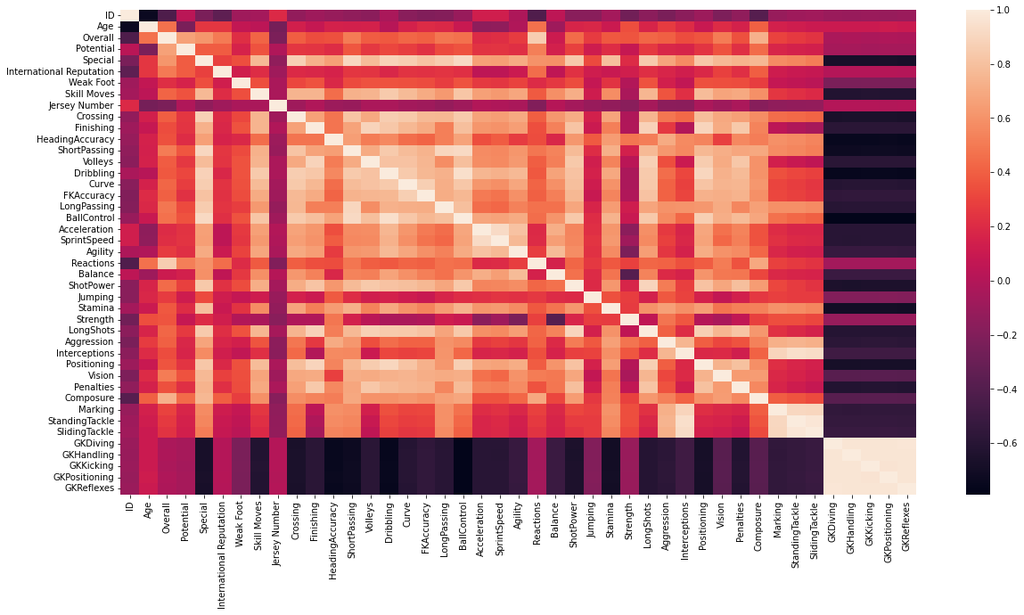

```python
plt.figure(figsize = (20,10))
sns.heatmap(df.corr())
```

## Exploratory Data Analysis

```python
#Taking subsets of data for analysis
df1 = df[['Name','Age','Nationality','Overall','Potential','Preferred Foot','Club','Special','International Reputation','Value','Wage',
                 'Weak Foot','Skill Moves','Work Rate','Body Type','Height','Weight','Release Clause']]
```

```python
#Seperate data frame for the numeric columns of df1 to analyse them statiscally later on.

numeric_features = ['Overall','Potential','Special','International Reputation','Weak Foot','Skill Moves']
numeric_dataset1 = df[numeric_features]
```

```python
df1.describe()
```

|  | Age | Overall | Potential | Special | International Reputation | Weak Foot | Skill Moves |
| --- | --- | --- | --- | --- | --- | --- | --- |
| count | 16643.000000 | 16643.000000 | 16643.000000 | 16643.000000 | 16643.000000 | 16643.000000 | 16643.000000 |
| mean | 25.226221 | 66.162771 | 71.140900 | 1595.383404 | 1.114823 | 2.942919 | 2.349516 |
| std | 4.716588 | 7.008236 | 6.151409 | 275.723076 | 0.398559 | 0.659933 | 0.755855 |
| min | 16.000000 | 46.000000 | 48.000000 | 731.000000 | 1.000000 | 1.000000 | 1.000000 |
| 25% | 21.000000 | 62.000000 | 67.000000 | 1452.000000 | 1.000000 | 3.000000 | 2.000000 |
| 50% | 25.000000 | 66.000000 | 71.000000 | 1633.000000 | 1.000000 | 3.000000 | 2.000000 |
| 75% | 29.000000 | 71.000000 | 75.000000 | 1787.000000 | 1.000000 | 3.000000 | 3.000000 |
| max | 45.000000 | 94.000000 | 95.000000 | 2346.000000 | 5.000000 | 5.000000 | 5.000000 |

#### Plot their histograms to look at their distributions.

```
array([[<AxesSubplot:title={'center':'Age'}>,
        <AxesSubplot:title={'center':'Overall'}>,
        <AxesSubplot:title={'center':'Potential'}>],
       [<AxesSubplot:title={'center':'Special'}>,
        <AxesSubplot:title={'center':'International Reputation'}>,
        <AxesSubplot:title={'center':'Weak Foot'}>],
       [<AxesSubplot:title={'center':'Skill Moves'}>, <AxesSubplot:>,
        <AxesSubplot:>]], dtype=object)
```

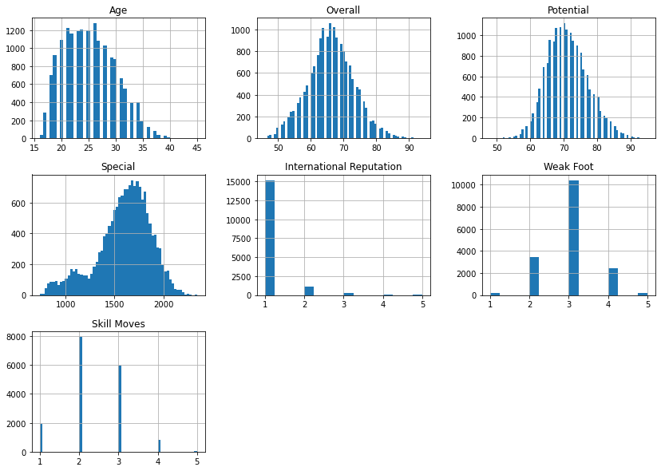

```python
#histograms of numerical features
df1.hist(bins='auto', figsize=(14, 10))
```

Observation: Maximum players are from the age group 20-30. Maximum and patterns of other features can be seen in the histograms too. International Reputation, Skill Moves and Weak Foot have categorical values. All other features have discrete values

#### Exploring Features: Age

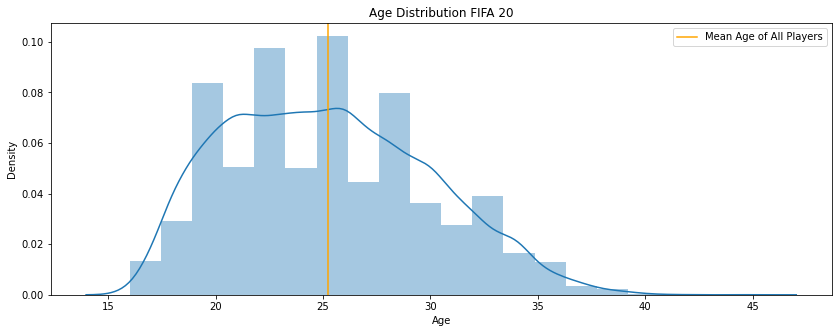

```python
plt.figure(figsize=(14,5))
plt.title('Age Distribution FIFA 20')
sns.distplot(a=df1['Age'], kde=True, bins=20)
plt.axvline(x=np.mean(df1['Age']),c='orange',label='Mean Age of All Players')
plt.legend()
```

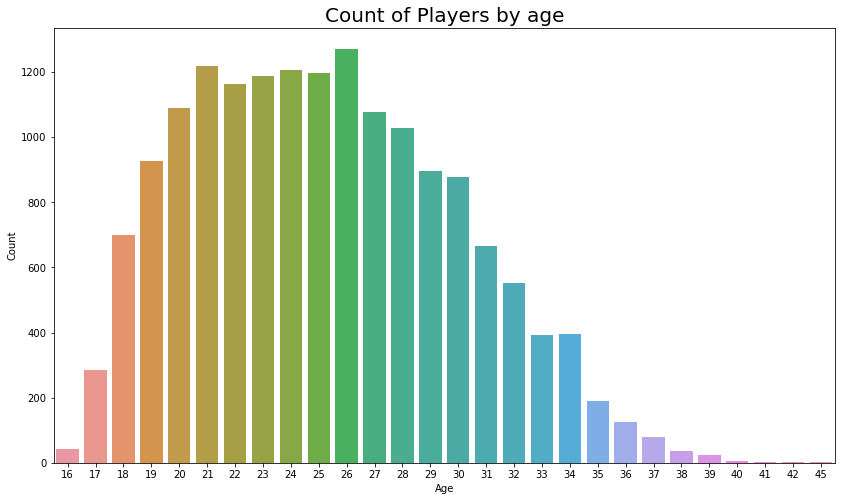

```python
#Count of players of different ages
plt.figure(figsize= (14,8))

ax = sns.countplot(x='Age', data=df1)
ax.set_title(label='Count of Players by age', fontsize=20)

ax.set_xlabel(xlabel='Age')
ax.set_ylabel(ylabel='Count')

plt.show()
```

```python
#Oldest Player
print("Oldest Players: ")
df.loc[df1['Age'] == df['Age'].max()]
```

```
Oldest Players:
```

|  | ID | Name | Age | Nationality | Overall | Potential | Club | Value | Wage | Special | Preferred Foot | International Reputation | Weak Foot | Skill Moves | Work Rate | Body Type | Jersey Number | Height | Weight | Crossing | Finishing | HeadingAccuracy | ShortPassing | Volleys | Dribbling | Curve | FKAccuracy | LongPassing | BallControl | … |
| --- | --- | --- | --- | --- | --- | --- | --- | --- | --- | --- | --- | --- | --- | --- | --- | --- | --- | --- | --- | --- | --- | --- | --- | --- | --- | --- | --- | --- | --- | --- |
| 4741 | 140029 | O. Pérez | 45 | Mexico | 71 | 71 | Pachuca | €160K | €8K | 1256 | Right | 2.0 | 3.0 | 1.0 | Medium/ Medium | Stocky | 21.0 | 5'8 | 165lbs | 19.0 | 14.0 | 24.0 | 26.0 | 13.0 | 12.0 | 12.0 | 20.0 | 27.0 | 23.0 | … |

```python
#Youngest Player
print("Youngest Players: ")
df.loc[df['Age'] == df1['Age'].min()]
```

```
Youngest Players:
```

|  | ID | Name | Age | Nationality | Overall | Potential | Club | Value | Wage | Special | Preferred Foot | International Reputation | Weak Foot | Skill Moves | Work Rate | Body Type | Jersey Number | Height | Weight | Crossing | Finishing | HeadingAccuracy | ShortPassing | Volleys | Dribbling | Curve | FKAccuracy | LongPassing | BallControl | … |
| --- | --- | --- | --- | --- | --- | --- | --- | --- | --- | --- | --- | --- | --- | --- | --- | --- | --- | --- | --- | --- | --- | --- | --- | --- | --- | --- | --- | --- | --- | --- |
| 11457 | 241266 | W. Geubbels | 16 | France | 64 | 86 | AS Monaco | €1M | €5K | 1576 | Right | 1.0 | 3.0 | 3.0 | Medium/ Low | Lean | 13.0 | 6'1 | 159lbs | 52.0 | 65.0 | 56.0 | 55.0 | 66.0 | 62.0 | 57.0 | 43.0 | 47.0 | 63.0 | … |
| 11732 | 244403 | A. Taoui | 16 | France | 64 | 75 | Toulouse Football Club | €700K | €3K | 1546 | Left | 1.0 | 4.0 | 3.0 | Medium/ Medium | Lean | 35.0 | 5'10 | 152lbs | 63.0 | 69.0 | 65.0 | 48.0 | 49.0 | 68.0 | 47.0 | 42.0 | 46.0 | 68.0 | … |
| 12496 | 245616 | Pelayo Morilla | 16 | Spain | 63 | 81 | Real Sporting de Gijón | €725K | €1K | 1558 | Left | 1.0 | 2.0 | 3.0 | Medium/ Medium | Lean | 31.0 | 6'0 | 154lbs | 63.0 | 61.0 | 52.0 | 63.0 | 58.0 | 69.0 | 57.0 | 44.0 | 55.0 | 66.0 | … |
| 12828 | 246465 | Guerrero | 16 | Spain | 63 | 76 | CF Rayo Majadahonda | €625K | €1K | 1645 | Left | 1.0 | 3.0 | 3.0 | Medium/ Medium | Normal | 26.0 | 5'11 | 165lbs | 50.0 | 51.0 | 57.0 | 67.0 | 42.0 | 64.0 | 49.0 | 43.0 | 61.0 | 66.0 | … |
| 13293 | 246594 | H. Massengo | 16 | France | 62 | 75 | AS Monaco | €450K | €2K | 1651 | Right | 1.0 | 3.0 | 2.0 | Medium/ Medium | Lean | 42.0 | 5'10 | 146lbs | 52.0 | 39.0 | 60.0 | 66.0 | 39.0 | 53.0 | 46.0 | 44.0 | 61.0 | 58.0 | … |
| 13567 | 246419 | Y. Verschaeren | 16 | Belgium | 62 | 83 | RSC Anderlecht | €650K | €1K | 1588 | Right | 1.0 | 3.0 | 3.0 | Medium/ Medium | Normal | 51.0 | 5'8 | 139lbs | 48.0 | 54.0 | 39.0 | 64.0 | 51.0 | 68.0 | 51.0 | 48.0 | 56.0 | 70.0 | … |
| 15363 | 245015 | Y. Roemer | 16 | Netherlands | 59 | 75 | VVV-Venlo | €300K | €1K | 1442 | Right | 1.0 | 2.0 | 3.0 | Medium/ Medium | Lean | 38.0 | 5'11 | 154lbs | 38.0 | 66.0 | 50.0 | 54.0 | 60.0 | 68.0 | 52.0 | 34.0 | 39.0 | 59.0 | … |
| 15746 | 243169 | Y. Begraoui | 16 | France | 59 | 81 | AJ Auxerre | €350K | €1K | 1434 | Right | 1.0 | 5.0 | 2.0 | High/ Low | Lean | 19.0 | 5'9 | 137lbs | 45.0 | 68.0 | 57.0 | 41.0 | 42.0 | 62.0 | 35.0 | 50.0 | 35.0 | 51.0 | … |
| 15793 | 241650 | J. Lahne | 16 | Sweden | 59 | 77 | IF Brommapojkarna | €300K | €1K | 1640 | Right | 1.0 | 3.0 | 2.0 | Medium/ Medium | Lean | 25.0 | 5'7 | 150lbs | 37.0 | 57.0 | 44.0 | 57.0 | 46.0 | 61.0 | 34.0 | 36.0 | 55.0 | 60.0 | … |
| 16081 | 241552 | J. Italiano | 16 | Australia | 58 | 79 | Perth Glory | €280K | €1K | 1434 | Right | 1.0 | 2.0 | 3.0 | High/ Medium | Lean | 26.0 | 5'7 | 143lbs | 43.0 | 50.0 | 36.0 | 61.0 | 35.0 | 59.0 | 41.0 | 36.0 | 57.0 | 56.0 | … |
| 16418 | 242531 | J. Kitolano | 16 | Norway | 57 | 75 | Odds BK | €200K | €1K | 1601 | Right | 1.0 | 3.0 | 2.0 | Medium/ Medium | Normal | 16.0 | 5'7 | 154lbs | 46.0 | 44.0 | 53.0 | 60.0 | 37.0 | 59.0 | 41.0 | 34.0 | 58.0 | 60.0 | … |
| 16544 | 240562 | D. Adshead | 16 | England | 57 | 77 | Rochdale | €200K | €1K | 1481 | Right | 1.0 | 2.0 | 2.0 | High/ Medium | Lean | 25.0 | 6'1 | 143lbs | 43.0 | 47.0 | 39.0 | 66.0 | 39.0 | 52.0 | 48.0 | 40.0 | 58.0 | 60.0 | … |
| 16927 | 243646 | B. Nygren | 16 | Sweden | 56 | 73 | IFK Göteborg | €180K | €1K | 1329 | Left | 1.0 | 3.0 | 2.0 | Medium/ Medium | Normal | 14.0 | 6'0 | 161lbs | 38.0 | 60.0 | 52.0 | 48.0 | 35.0 | 47.0 | 37.0 | 30.0 | 36.0 | 55.0 | … |
| 17091 | 243269 | A. Doğan | 16 | Turkey | 55 | 71 | Kayserispor | €160K | €1K | 1269 | Right | 1.0 | 2.0 | 2.0 | Low/ Medium | Lean | 30.0 | 5'11 | 154lbs | 29.0 | 22.0 | 52.0 | 40.0 | 28.0 | 34.0 | 26.0 | 33.0 | 30.0 | 36.0 | … |
| 17115 | 245341 | C. Bassett | 16 | United States | 55 | 77 | Colorado Rapids | €180K | €1K | 1555 | Right | 1.0 | 3.0 | 2.0 | Medium/ Medium | Lean | 26.0 | 5'11 | 148lbs | 57.0 | 44.0 | 47.0 | 60.0 | 34.0 | 55.0 | 49.0 | 48.0 | 56.0 | 55.0 | … |
| 17175 | 243353 | B. Mumba | 16 | England | 55 | 80 | Sunderland | €190K | €1K | 1485 | Right | 1.0 | 3.0 | 2.0 | Medium/ High | Lean | 37.0 | 5'6 | 126lbs | 42.0 | 33.0 | 50.0 | 63.0 | 31.0 | 52.0 | 42.0 | 36.0 | 56.0 | 55.0 | … |
| 17177 | 242074 | R. Gómez | 16 | Argentina | 55 | 76 | Belgrano de Córdoba | €190K | €1K | 1405 | Right | 1.0 | 3.0 | 2.0 | Medium/ Low | Lean | 18.0 | 5'7 | 143lbs | 55.0 | 53.0 | 37.0 | 51.0 | 48.0 | 60.0 | 53.0 | 41.0 | 44.0 | 55.0 | … |
| 17200 | 245171 | H. Andersson | 16 | Sweden | 55 | 70 | Örebro SK | €160K | €1K | 1190 | Right | 1.0 | 2.0 | 2.0 | Medium/ Medium | Normal | 46.0 | 6'3 | 150lbs | 22.0 | 24.0 | 58.0 | 38.0 | 23.0 | 28.0 | 27.0 | 23.0 | 26.0 | 31.0 | … |
| 17263 | 245485 | P. Samiec-Talar | 16 | Poland | 55 | 73 | Śląsk Wrocław | €180K | €1K | 1361 | Right | 1.0 | 3.0 | 2.0 | Medium/ Medium | Normal | 24.0 | 5'11 | 154lbs | 31.0 | 57.0 | 66.0 | 45.0 | 44.0 | 54.0 | 33.0 | 31.0 | 34.0 | 57.0 | … |
| 17354 | 242240 | L. D'Arrigo | 16 | Australia | 54 | 71 | Adelaide United | €130K | €1K | 1344 | Right | 1.0 | 3.0 | 2.0 | Medium/ Medium | Lean | 27.0 | 5'9 | 154lbs | 34.0 | 40.0 | 48.0 | 55.0 | 32.0 | 53.0 | 31.0 | 35.0 | 52.0 | 56.0 | … |
| 17712 | 245470 | K. Broda | 16 | Poland | 53 | 74 | Wisła Kraków | €110K | €1K | 784 | Right | 1.0 | 2.0 | 1.0 | Medium/ Medium | Normal | 48.0 | 6'3 | 187lbs | 11.0 | 8.0 | 13.0 | 29.0 | 7.0 | 6.0 | 11.0 | 14.0 | 15.0 | 14.0 | … |
| 17743 | 244752 | J. Olstad | 16 | Norway | 52 | 69 | Sarpsborg 08 FF | €100K | €1K | 1308 | Right | 1.0 | 3.0 | 2.0 | Medium/ Medium | Lean | 25.0 | 5'8 | 150lbs | 28.0 | 53.0 | 49.0 | 48.0 | 41.0 | 51.0 | 36.0 | 31.0 | 31.0 | 53.0 | … |
| 17751 | 245537 | E. Ceide | 16 | Norway | 52 | 75 | Rosenborg BK | €110K | €1K | 1320 | Right | 1.0 | 2.0 | 2.0 | Medium/ Medium | Lean | 35.0 | 5'9 | 154lbs | 50.0 | 44.0 | 37.0 | 45.0 | 49.0 | 53.0 | 46.0 | 40.0 | 42.0 | 53.0 | … |
| 17753 | 245539 | B. Waine | 16 | New Zealand | 52 | 66 | Wellington Phoenix | €100K | €1K | 1279 | Right | 1.0 | 3.0 | 2.0 | High/ Medium | Lean | 24.0 | 5'9 | 165lbs | 29.0 | 55.0 | 50.0 | 42.0 | 34.0 | 52.0 | 30.0 | 33.0 | 26.0 | 52.0 | … |
| 17757 | 246315 | L. Smyth | 16 | Northern Ireland | 52 | 73 | Stevenage | €110K | €1K | 1331 | Right | 1.0 | 3.0 | 2.0 | Medium/ Medium | Normal | 29.0 | 5'10 | 159lbs | 31.0 | 53.0 | 49.0 | 38.0 | 54.0 | 47.0 | 49.0 | 42.0 | 36.0 | 48.0 | … |
| 17776 | 244553 | M. Köstenbauer | 16 | Austria | 52 | 74 | FC Admira Wacker Mödling | €90K | €1K | 797 | Right | 1.0 | 3.0 | 1.0 | Medium/ Medium | Lean | 28.0 | 6'1 | 154lbs | 11.0 | 5.0 | 12.0 | 15.0 | 7.0 | 14.0 | 10.0 | 12.0 | 17.0 | 15.0 | … |
| 17808 | 245123 | A. Mahlonoko | 16 | South Africa | 52 | 71 | Orlando Pirates | €100K | €1K | 1371 | Right | 1.0 | 3.0 | 2.0 | High/ Medium | Lean | 38.0 | 5'8 | 130lbs | 26.0 | 52.0 | 66.0 | 45.0 | 50.0 | 54.0 | 36.0 | 34.0 | 34.0 | 56.0 | … |
| 17841 | 244925 | F. Tauchhammer | 16 | Austria | 52 | 71 | Wolfsberger AC | €90K | €1K | 1315 | Right | 1.0 | 3.0 | 2.0 | Medium/ Medium | Lean | 25.0 | 6'0 | 141lbs | 46.0 | 17.0 | 40.0 | 47.0 | 27.0 | 49.0 | 29.0 | 28.0 | 28.0 | 46.0 | … |
| 17881 | 242165 | R. Hauge | 16 | Norway | 52 | 67 | FK Bodø/Glimt | €100K | €1K | 1457 | Right | 1.0 | 2.0 | 2.0 | Medium/ Medium | Normal | 34.0 | 5'9 | 154lbs | 34.0 | 46.0 | 46.0 | 58.0 | 46.0 | 51.0 | 50.0 | 30.0 | 54.0 | 54.0 | … |
| 17887 | 246009 | M. Tilio | 16 | Australia | 52 | 69 | Sydney FC | €100K | €1K | 1420 | Left | 1.0 | 3.0 | 2.0 | Medium/ Medium | Normal | 27.0 | 5'7 | 148lbs | 47.0 | 53.0 | 40.0 | 56.0 | 37.0 | 48.0 | 58.0 | 49.0 | 45.0 | 51.0 | … |
| 17921 | 246601 | J. Rowland | 16 | England | 51 | 66 | Shrewsbury | €70K | €1K | 1334 | Right | 1.0 | 3.0 | 2.0 | Medium/ Medium | Lean | 35.0 | 5'5 | 143lbs | 44.0 | 40.0 | 39.0 | 51.0 | 43.0 | 55.0 | 40.0 | 36.0 | 46.0 | 53.0 | … |
| 17976 | 243891 | M. Larsen | 16 | Denmark | 51 | 71 | Esbjerg fB | €70K | €1K | 1348 | Right | 1.0 | 2.0 | 2.0 | Medium/ Medium | Lean | 50.0 | 5'11 | 152lbs | 46.0 | 42.0 | 46.0 | 60.0 | 35.0 | 50.0 | 44.0 | 40.0 | 56.0 | 51.0 | … |
| 18003 | 239594 | J. Imbrechts | 16 | Sweden | 51 | 72 | Sporting de Charleroi | €70K | €1K | 790 | Right | 1.0 | 2.0 | 1.0 | Medium/ Medium | Lean | 12.0 | 5'11 | 150lbs | 9.0 | 4.0 | 13.0 | 23.0 | 8.0 | 8.0 | 12.0 | 11.0 | 15.0 | 11.0 | … |
| 18018 | 243722 | B. O'Gorman | 16 | Republic of Ireland | 50 | 69 | Bray Wanderers | €60K | €1K | 1261 | Right | 1.0 | 3.0 | 2.0 | Medium/ Medium | Normal | 26.0 | 5'9 | 161lbs | 42.0 | 48.0 | 47.0 | 46.0 | 35.0 | 47.0 | 31.0 | 31.0 | 44.0 | 47.0 | … |
| 18044 | 246109 | K. Lara | 16 | Colombia | 50 | 74 | Atlético Huila | €60K | €1K | 1271 | Right | 1.0 | 3.0 | 2.0 | Medium/ Medium | Lean | 3.0 | 5'7 | 143lbs | 36.0 | 27.0 | 44.0 | 41.0 | 22.0 | 50.0 | 25.0 | 26.0 | 27.0 | 46.0 | … |
| 18106 | 243685 | J. Cleary | 16 | Republic of Ireland | 50 | 72 | Bohemian FC | €50K | €1K | 814 | Right | 1.0 | 2.0 | 1.0 | Medium/ Medium | Normal | 30.0 | 5'10 | 159lbs | 11.0 | 7.0 | 10.0 | 24.0 | 5.0 | 8.0 | 10.0 | 13.0 | 17.0 | 10.0 | … |
| 18124 | 245808 | G. Hollywood | 16 | Republic of Ireland | 49 | 67 | Bray Wanderers | €60K | €1K | 1367 | Right | 1.0 | 2.0 | 2.0 | Medium/ Medium | Lean | 16.0 | 5'10 | 146lbs | 38.0 | 45.0 | 35.0 | 52.0 | 39.0 | 49.0 | 40.0 | 40.0 | 50.0 | 51.0 | … |
| 18162 | 243866 | T. Gundelund | 16 | Denmark | 48 | 66 | Vejle Boldklub | €50K | €1K | 1244 | Right | 1.0 | 3.0 | 2.0 | Medium/ Medium | Lean | 14.0 | 5'11 | 154lbs | 40.0 | 24.0 | 38.0 | 36.0 | 26.0 | 52.0 | 30.0 | 25.0 | 28.0 | 46.0 | … |
| 18166 | 243621 | N. Ayéva | 16 | Sweden | 48 | 72 | Örebro SK | €70K | €1K | 1286 | Right | 1.0 | 3.0 | 2.0 | Medium/ Medium | Normal | 23.0 | 5'10 | 154lbs | 34.0 | 47.0 | 42.0 | 43.0 | 40.0 | 50.0 | 45.0 | 32.0 | 30.0 | 46.0 | … |
| 18204 | 241638 | B. Worman | 16 | England | 47 | 67 | Cambridge United | €60K | €1K | 1189 | Right | 1.0 | 3.0 | 2.0 | Medium/ Medium | Normal | 33.0 | 5'8 | 148lbs | 25.0 | 40.0 | 46.0 | 38.0 | 38.0 | 45.0 | 38.0 | 27.0 | 28.0 | 44.0 | … |
| 18206 | 246269 | G. Nugent | 16 | England | 46 | 66 | Tranmere Rovers | €60K | €1K | 1321 | Right | 1.0 | 3.0 | 2.0 | Medium/ Medium | Lean | 33.0 | 5'10 | 176lbs | 41.0 | 34.0 | 46.0 | 48.0 | 30.0 | 43.0 | 40.0 | 34.0 | 44.0 | 51.0 | … |

Hence the youngest players are of age 16

```python
#Skewness
df1['Age'].skew()
```

```
0.33737127650526305
```

#### Nationality of different players

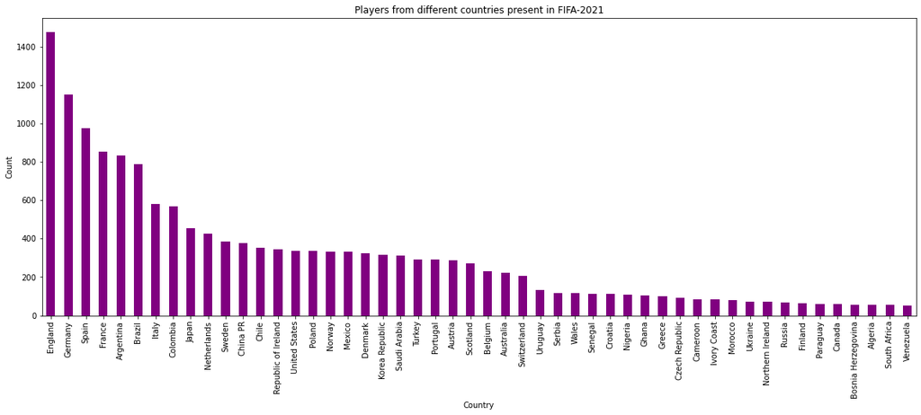

```python
plt.figure(figsize = (20,7))
df1['Nationality'].value_counts().head(50).plot.bar(color = 'purple')
plt.title('Players from different countries present in FIFA-2021')
plt.xlabel('Country')
plt.ylabel('Count')
plt.show()
```

#### Nationality vs Overall Rating

```python
fig = go.Figure()

fig = go.Figure(data=go.Scatter(
    x = df1['Nationality'],
    y = df1['Overall'],
    mode='markers',
    marker=dict(
        color=df1['Overall'],
        showscale=True
    ),
    text= df1['Name'],
))

fig.update_layout(title='Nationality vs Overall Rating',
                  xaxis_title='Nationality',
                  yaxis_title='Overall Rating')
fig.show()
```

[interactive chart not shown]

Argetina Players have the highest maximum rating. Bostwana has least maximum rating.

### Overall

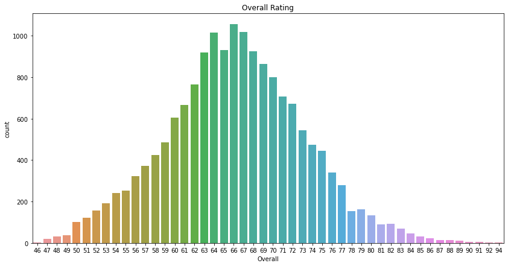

```python
plt.figure(figsize=(14, 7))
sns.countplot(df1['Overall'])
plt.title("Overall Rating")
plt.show()
```

Most players have rating in range 63-68. And very few players have rating > 80.

#### mean, min and max values of the data

```python
print("Min: ", df1['Overall'].min())
print("Mean: ", df1['Overall'].mean())
print("Max: ", df1['Overall'].max())
```

```
Min:  46
Mean:  66.16277113501171
Max:  94
```

```python
#Player with highest rating
df.loc[df['Overall'] == df1['Overall'].max()]
```

|  | ID | Name | Age | Nationality | Overall | Potential | Club | Value | Wage | Special | Preferred Foot | International Reputation | Weak Foot | Skill Moves | Work Rate | Body Type | Jersey Number | Height | Weight | Crossing | Finishing | HeadingAccuracy | ShortPassing | Volleys | Dribbling | Curve | FKAccuracy | LongPassing | BallControl | … |
| --- | --- | --- | --- | --- | --- | --- | --- | --- | --- | --- | --- | --- | --- | --- | --- | --- | --- | --- | --- | --- | --- | --- | --- | --- | --- | --- | --- | --- | --- | --- |
| 0 | 158023 | L. Messi | 31 | Argentina | 94 | 94 | FC Barcelona | €110.5M | €565K | 2202 | Left | 5.0 | 4.0 | 4.0 | Medium/ Medium | Messi | 10.0 | 5'7 | 159lbs | 84.0 | 95.0 | 70.0 | 90.0 | 86.0 | 97.0 | 93.0 | 94.0 | 87.0 | 96.0 | … |
| 1 | 20801 | Cristiano Ronaldo | 33 | Portugal | 94 | 94 | Juventus | €77M | €405K | 2228 | Right | 5.0 | 4.0 | 5.0 | High/ Low | C. Ronaldo | 7.0 | 6'2 | 183lbs | 84.0 | 94.0 | 89.0 | 81.0 | 87.0 | 88.0 | 81.0 | 76.0 | 77.0 | 94.0 | … |

```python
#Top 10 Players
top_rated = df.sort_values(by=["Overall"], ascending=False)
top_rated.head(10)
```

|  | ID | Name | Age | Nationality | Overall | Potential | Club | Value | Wage | Special | Preferred Foot | International Reputation | Weak Foot | Skill Moves | Work Rate | Body Type | Jersey Number | Height | Weight | Crossing | Finishing | HeadingAccuracy | ShortPassing | Volleys | Dribbling | Curve | FKAccuracy | LongPassing | BallControl | … |
| --- | --- | --- | --- | --- | --- | --- | --- | --- | --- | --- | --- | --- | --- | --- | --- | --- | --- | --- | --- | --- | --- | --- | --- | --- | --- | --- | --- | --- | --- | --- |
| 0 | 158023 | L. Messi | 31 | Argentina | 94 | 94 | FC Barcelona | €110.5M | €565K | 2202 | Left | 5.0 | 4.0 | 4.0 | Medium/ Medium | Messi | 10.0 | 5'7 | 159lbs | 84.0 | 95.0 | 70.0 | 90.0 | 86.0 | 97.0 | 93.0 | 94.0 | 87.0 | 96.0 | … |
| 1 | 20801 | Cristiano Ronaldo | 33 | Portugal | 94 | 94 | Juventus | €77M | €405K | 2228 | Right | 5.0 | 4.0 | 5.0 | High/ Low | C. Ronaldo | 7.0 | 6'2 | 183lbs | 84.0 | 94.0 | 89.0 | 81.0 | 87.0 | 88.0 | 81.0 | 76.0 | 77.0 | 94.0 | … |
| 2 | 190871 | Neymar Jr | 26 | Brazil | 92 | 93 | Paris Saint-Germain | €118.5M | €290K | 2143 | Right | 5.0 | 5.0 | 5.0 | High/ Medium | Neymar | 10.0 | 5'9 | 150lbs | 79.0 | 87.0 | 62.0 | 84.0 | 84.0 | 96.0 | 88.0 | 87.0 | 78.0 | 95.0 | … |
| 3 | 193080 | De Gea | 27 | Spain | 91 | 93 | Manchester United | €72M | €260K | 1471 | Right | 4.0 | 3.0 | 1.0 | Medium/ Medium | Lean | 1.0 | 6'4 | 168lbs | 17.0 | 13.0 | 21.0 | 50.0 | 13.0 | 18.0 | 21.0 | 19.0 | 51.0 | 42.0 | … |
| 4 | 192985 | K. De Bruyne | 27 | Belgium | 91 | 92 | Manchester City | €102M | €355K | 2281 | Right | 4.0 | 5.0 | 4.0 | High/ High | Normal | 7.0 | 5'11 | 154lbs | 93.0 | 82.0 | 55.0 | 92.0 | 82.0 | 86.0 | 85.0 | 83.0 | 91.0 | 91.0 | … |
| 5 | 183277 | E. Hazard | 27 | Belgium | 91 | 91 | Chelsea | €93M | €340K | 2142 | Right | 4.0 | 4.0 | 4.0 | High/ Medium | Normal | 10.0 | 5'8 | 163lbs | 81.0 | 84.0 | 61.0 | 89.0 | 80.0 | 95.0 | 83.0 | 79.0 | 83.0 | 94.0 | … |
| 6 | 177003 | L. Modrić | 32 | Croatia | 91 | 91 | Real Madrid | €67M | €420K | 2280 | Right | 4.0 | 4.0 | 4.0 | High/ High | Lean | 10.0 | 5'8 | 146lbs | 86.0 | 72.0 | 55.0 | 93.0 | 76.0 | 90.0 | 85.0 | 78.0 | 88.0 | 93.0 | … |
| 7 | 176580 | L. Suárez | 31 | Uruguay | 91 | 91 | FC Barcelona | €80M | €455K | 2346 | Right | 5.0 | 4.0 | 3.0 | High/ Medium | Normal | 9.0 | 6'0 | 190lbs | 77.0 | 93.0 | 77.0 | 82.0 | 88.0 | 87.0 | 86.0 | 84.0 | 64.0 | 90.0 | … |
| 8 | 155862 | Sergio Ramos | 32 | Spain | 91 | 91 | Real Madrid | €51M | €380K | 2201 | Right | 4.0 | 3.0 | 3.0 | High/ Medium | Normal | 15.0 | 6'0 | 181lbs | 66.0 | 60.0 | 91.0 | 78.0 | 66.0 | 63.0 | 74.0 | 72.0 | 77.0 | 84.0 | … |
| 12 | 182493 | D. Godín | 32 | Uruguay | 90 | 90 | Atlético Madrid | €44M | €125K | 1946 | Right | 3.0 | 3.0 | 2.0 | Medium/ High | Lean | 10.0 | 6'2 | 172lbs | 55.0 | 42.0 | 92.0 | 79.0 | 47.0 | 53.0 | 49.0 | 51.0 | 70.0 | 76.0 | … |

### Potential

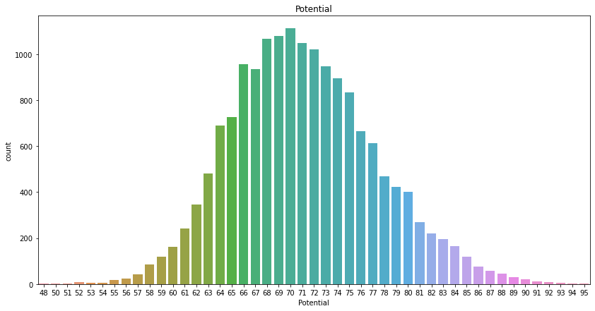

```python
plt.figure(figsize=(14,7))
sns.countplot(df['Potential'])
plt.title('Potential')
plt.show()
```

#### Club of Players

```python
fig = px.pie(top_rated.head(25), names='Club',
             title='Percentage of Clubs in top 25 players')
fig.show()
```

[interactive chart not shown]

#### Preferred Foot

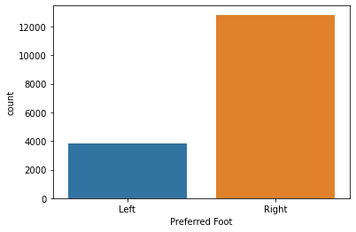

```python
sns.countplot(x = df1['Preferred Foot'])
```

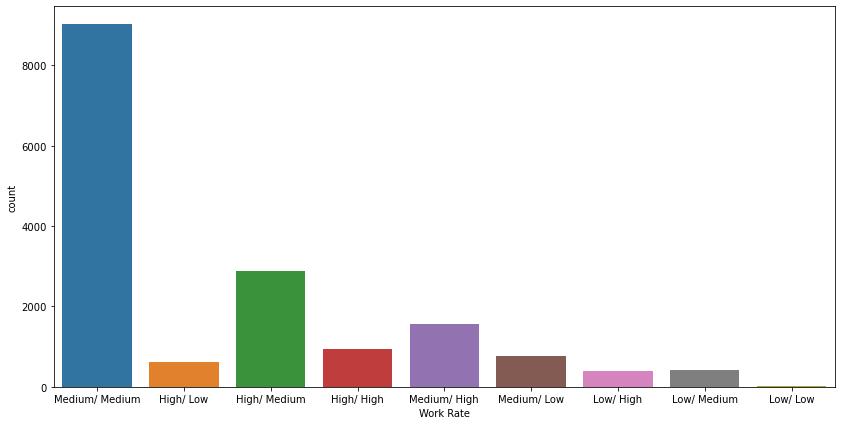

```python
plt.figure(figsize=(14,7))
sns.countplot(x = df1['Work Rate'])
```

#### Correlation Heatmap

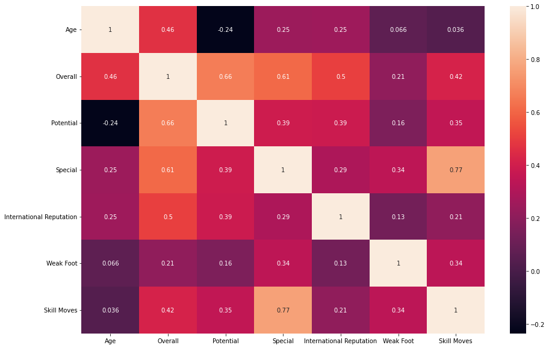

```python
plt.figure(figsize=(15,10))
sns.heatmap(df1.corr(), annot=True, cbar=True)
```